# PA4

## Programming Assignment - 4: Autoencoders

## Loading the data

```python
# import packages
import random
import numpy as np
import seaborn as sns
import cv2 as cv
import matplotlib.pyplot as plt
import sklearn
import torch
import torch.nn as nn
import torch.nn.functional as F
from torch.autograd import Variable
import torch.optim as optim
from torch.utils.data import DataLoader, Subset
import torchvision
import torchvision.transforms as transforms
from torchsummary import summary
from sklearn.decomposition import PCA
from sklearn.model_selection import train_test_split
from sklearn.metrics import accuracy_score, classification_report, confusion_matrix, ConfusionMatrixDisplay

%matplotlib inline
plt.rcParams['figure.figsize'] = (7.0, 4.0) # set default size of plots
plt.rcParams['image.interpolation'] = 'nearest'
plt.rcParams['image.cmap'] = 'gray'
```

```python
mnist_train = torchvision.datasets.MNIST(root = 'MNIST', download = True, transform = transforms.ToTensor())
mnist_data_test = torchvision.datasets.MNIST(root = 'MNIST', train = False, download = True, transform = transforms.ToTensor())
```

```python
train_indices, val_indices, _, _ = train_test_split(
    range(len(mnist_train)),
    mnist_train.targets,
    stratify = mnist_train.targets,
    test_size = 0.2,
    random_state = 42
)

# generate subset based on indices
mnist_data_train = Subset(mnist_train, train_indices)
mnist_data_val = Subset(mnist_train, val_indices)
```

```python
# Parameters

BATCH_SIZE = 64
CLASSES = 10
```

```python
train_loader = DataLoader(dataset = mnist_data_train, batch_size = BATCH_SIZE, shuffle = True)
val_loader = DataLoader(dataset = mnist_data_val, batch_size = len(mnist_data_val), shuffle = False)
test_loader = DataLoader(dataset = mnist_data_test, batch_size = len(mnist_data_test), shuffle = False)
```

```python
fashion_data_test = torchvision.datasets.FashionMNIST(root = 'FashionMNIST', train = False, download = True, transform = transforms.ToTensor())
```

```python
fashion_test_loader = DataLoader(dataset = fashion_data_test, batch_size = len(fashion_data_test), shuffle = False)
```

## Comparing PCA and Autoencoders

### PCA

```python
X, y = iter(DataLoader(dataset = mnist_data_train, batch_size = len(mnist_data_train), shuffle = False)).next()
# val_loader = DataLoader(dataset = mnist_data_val, batch_size = len(mnist_data_val), shuffle = False)
# test_loader = DataLoader(dataset = mnist_data_test, batch_size = len(mnist_data_test), shuffle = False)
```

```python
X = np.array(X.view(-1, 28*28))
y = np.array(y)
```

```python
pca = PCA(n_components = 30)
pca.fit(X)
```

```
PCA(n_components=30)
```

```python
pca.explained_variance_ratio_.sum()
```

```
0.7306478
```

```python
X_hat = pca.inverse_transform(pca.transform(X))
```

### Reconstruction Accuracy

```python
((X - X_hat) ** 2).mean()
```

```
0.018129006
```

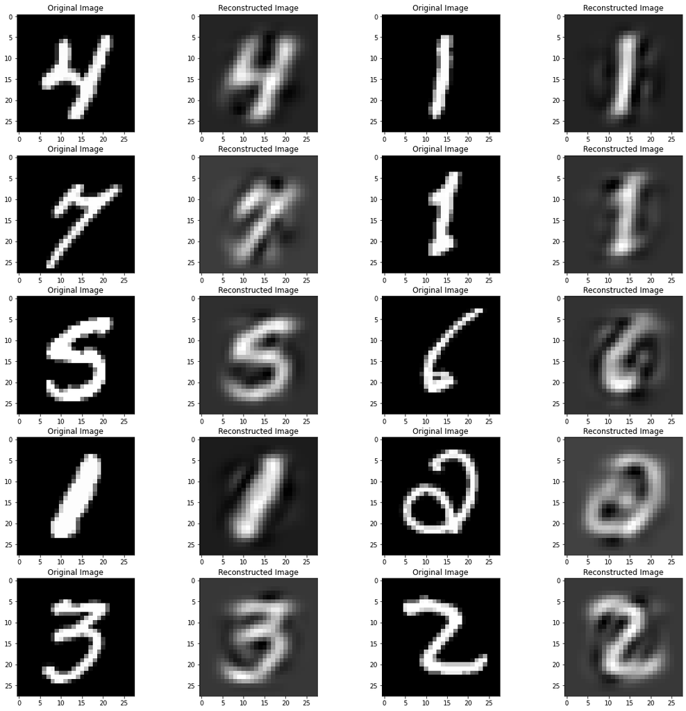

```python
fig, ax = plt.subplots(5, 4, figsize = (20, 20))
for i in range(10):
  r = i // 2
  c = 2 * (i % 2)
  idx = random.randint(0, len(mnist_data_train) - 1)
  image = X[idx].reshape(28, 28)
  image_hat = X_hat[idx].reshape(28, 28)
  ax[r, c].imshow(image)
  ax[r, c + 1].imshow(image_hat)
  ax[r, c].set_title('Original Image')
  ax[r, c + 1].set_title('Reconstructed Image')
```

### Autoencoders

```python
class AutoEncoder(nn.Module):

    def __init__(self):
        super().__init__()
        self.encoder = nn.Sequential(nn.Flatten(),
                                     nn.Linear(784, 512),
                                     nn.ReLU(),
                                     nn.Linear(512, 256),
                                     nn.ReLU(),
                                     nn.Linear(256, 128),
                                     nn.ReLU(),
                                     nn.Linear(128, 30))
        self.decoder = nn.Sequential(nn.Linear(30, 128),
                                     nn.ReLU(),
                                     nn.Linear(128, 256),
                                     nn.ReLU(),
                                     nn.Linear(256, 784))

    def forward(self, x):
        h = self.encoder(x)
        x_hat = self.decoder(h)
        return x_hat
```

```python
model = AutoEncoder()
```

```python
criterion = nn.MSELoss()
optimizer = optim.Adam(model.parameters(), lr = 0.001)
```

```python
train_costs = []
val_costs = []

for epoch in range(2):  # loop over the dataset multiple times

    running_loss = 0.0
    for i, data in enumerate(train_loader, 0):
        # get the inputs; data is a list of [inputs, labels]
        inputs, labels = data

        # zero the parameter gradients
        optimizer.zero_grad()

        # forward + backward + optimize
        outputs = model(inputs)
        loss = criterion(outputs, inputs.view(-1, 28*28))
        loss.backward()
        optimizer.step()

        if i % 200 == 0:
          train_costs.append(loss.item())
          for j, data in enumerate(val_loader, 0):
            inputs, labels = data
            outputs = model(inputs)
            val_loss = criterion(outputs, inputs.view(-1, 28*28))
            val_costs.append(val_loss.item())
          # Print Loss
          print('Epoch: {}. Iteration: {}. Train Loss: {}. Validation Loss: {}'.format(epoch, i, loss.item(), val_loss.item()))

print('Finished Training')
```

```
Epoch: 0. Iteration: 0. Train Loss: 0.11311082541942596. Validation Loss: 0.11058305948972702
Epoch: 0. Iteration: 200. Train Loss: 0.033849138766527176. Validation Loss: 0.035949934273958206
Epoch: 0. Iteration: 400. Train Loss: 0.028410032391548157. Validation Loss: 0.028682440519332886
Epoch: 0. Iteration: 600. Train Loss: 0.025468898937106133. Validation Loss: 0.024571703746914864
Epoch: 1. Iteration: 0. Train Loss: 0.022897329181432724. Validation Loss: 0.02304096519947052
Epoch: 1. Iteration: 200. Train Loss: 0.021468184888362885. Validation Loss: 0.02133365534245968
Epoch: 1. Iteration: 400. Train Loss: 0.01933327317237854. Validation Loss: 0.019822459667921066
Epoch: 1. Iteration: 600. Train Loss: 0.019935226067900658. Validation Loss: 0.018781276419758797
Finished Training
```

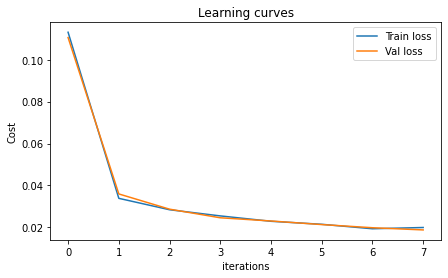

```python
# Plot the cost
plt.plot(train_costs)
plt.plot(val_costs)
plt.ylabel('Cost')
plt.xlabel('iterations')
plt.title('Learning curves')
plt.legend(['Train loss', 'Val loss'])
plt.show()
```

### Reconstruction Accuracy

```python
inputs, labels = iter(test_loader).next()
outputs = model(inputs)
```

```python
criterion(outputs, inputs.view(-1, 28*28))
```

```
tensor(0.0178, grad_fn=<MseLossBackward0>)
```

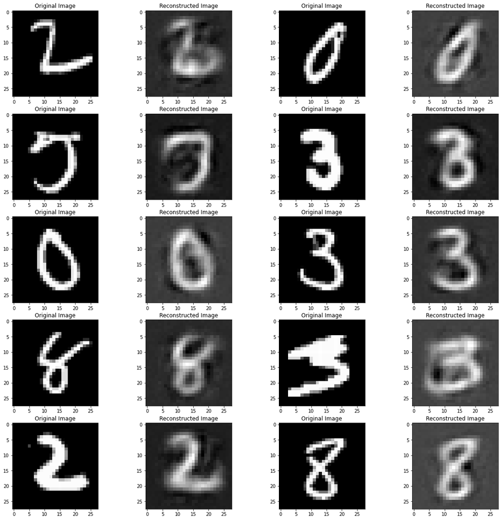

```python
fig, ax = plt.subplots(5, 4, figsize = (20, 20))
for i in range(10):
  r = i // 2
  c = 2 * (i % 2)
  idx = random.randint(0, len(mnist_data_test) - 1)
  image = inputs[idx].view(28, 28)
  image_hat = outputs[idx].view(28, 28)
  ax[r, c].imshow(image)
  ax[r, c + 1].imshow(image_hat.detach().numpy())
  ax[r, c].set_title('Original Image')
  ax[r, c + 1].set_title('Reconstructed Image')
```

PCA and Autoencoder with hidden code size 30 perform similarly, in terms of reconstruction accuracy and visual quality of the output images

## Experimenting with hidden units of varying sizes

```python
class AutoEncoder(nn.Module):

    def __init__(self, latent_dim):
        super().__init__()
        self.encoder = nn.Sequential(nn.Flatten(),
                                     nn.Linear(784, latent_dim))
        self.decoder = nn.Sequential(nn.Linear(latent_dim, 784))

    def forward(self, x):
        h = self.encoder(x)
        x_hat = self.decoder(h)
        return x_hat
```

### Latent dimension - 64

```python
model = AutoEncoder(latent_dim = 64)
```

```python
criterion = nn.MSELoss()
optimizer = optim.Adam(model.parameters(), lr = 0.001)
```

```python
train_costs = []
val_costs = []

for epoch in range(2):  # loop over the dataset multiple times

    running_loss = 0.0
    for i, data in enumerate(train_loader, 0):
        # get the inputs; data is a list of [inputs, labels]
        inputs, labels = data

        # zero the parameter gradients
        optimizer.zero_grad()

        # forward + backward + optimize
        outputs = model(inputs)
        loss = criterion(outputs, inputs.view(-1, 28*28))
        loss.backward()
        optimizer.step()

        if i % 200 == 0:
          train_costs.append(loss.item())
          for j, data in enumerate(val_loader, 0):
            inputs, labels = data
            outputs = model(inputs)
            val_loss = criterion(outputs, inputs.view(-1, 28*28))
            val_costs.append(val_loss.item())
          # Print Loss
          print('Epoch: {}. Iteration: {}. Train Loss: {}. Validation Loss: {}'.format(epoch, i, loss.item(), val_loss.item()))

print('Finished Training')
```

```
Epoch: 0. Iteration: 0. Train Loss: 0.13058708608150482. Validation Loss: 0.1217784732580185
Epoch: 0. Iteration: 200. Train Loss: 0.023721903562545776. Validation Loss: 0.025149039924144745
Epoch: 0. Iteration: 400. Train Loss: 0.017774509266018867. Validation Loss: 0.016816575080156326
Epoch: 0. Iteration: 600. Train Loss: 0.013108543120324612. Validation Loss: 0.013511374592781067
Epoch: 1. Iteration: 0. Train Loss: 0.012043086811900139. Validation Loss: 0.012155138887465
Epoch: 1. Iteration: 200. Train Loss: 0.01147869136184454. Validation Loss: 0.01105461921542883
Epoch: 1. Iteration: 400. Train Loss: 0.009727340191602707. Validation Loss: 0.010391980409622192
Epoch: 1. Iteration: 600. Train Loss: 0.00979645736515522. Validation Loss: 0.010031434707343578
Finished Training
```

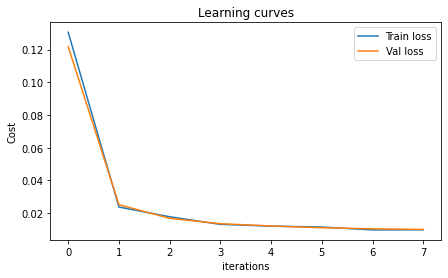

```python
# Plot the cost
plt.plot(train_costs)
plt.plot(val_costs)
plt.ylabel('Cost')
plt.xlabel('iterations')
plt.title('Learning curves')
plt.legend(['Train loss', 'Val loss'])
plt.show()
```

### Reconstruction Accuracy

```python
inputs, labels = iter(test_loader).next()
outputs = model(inputs)
```

```python
criterion(outputs, inputs.view(-1, 28*28))
```

```
tensor(0.0096, grad_fn=<MseLossBackward0>)
```

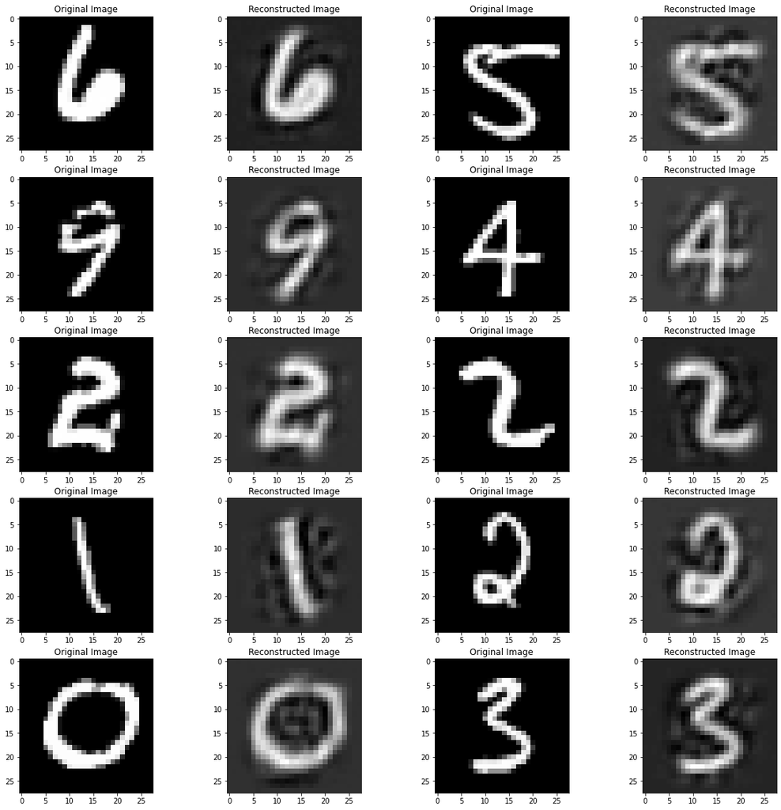

```python
fig, ax = plt.subplots(5, 4, figsize = (20, 20))
for i in range(10):
  r = i // 2
  c = 2 * (i % 2)
  idx = random.randint(0, len(mnist_data_test) - 1)
  image = inputs[idx].view(28, 28)
  image_hat = outputs[idx].view(28, 28)
  ax[r, c].imshow(image)
  ax[r, c + 1].imshow(image_hat.detach().numpy())
  ax[r, c].set_title('Original Image')
  ax[r, c + 1].set_title('Reconstructed Image')
```

### Fashion MNIST images

```python
inputs, labels = iter(fashion_test_loader).next()
outputs = model(inputs)
```

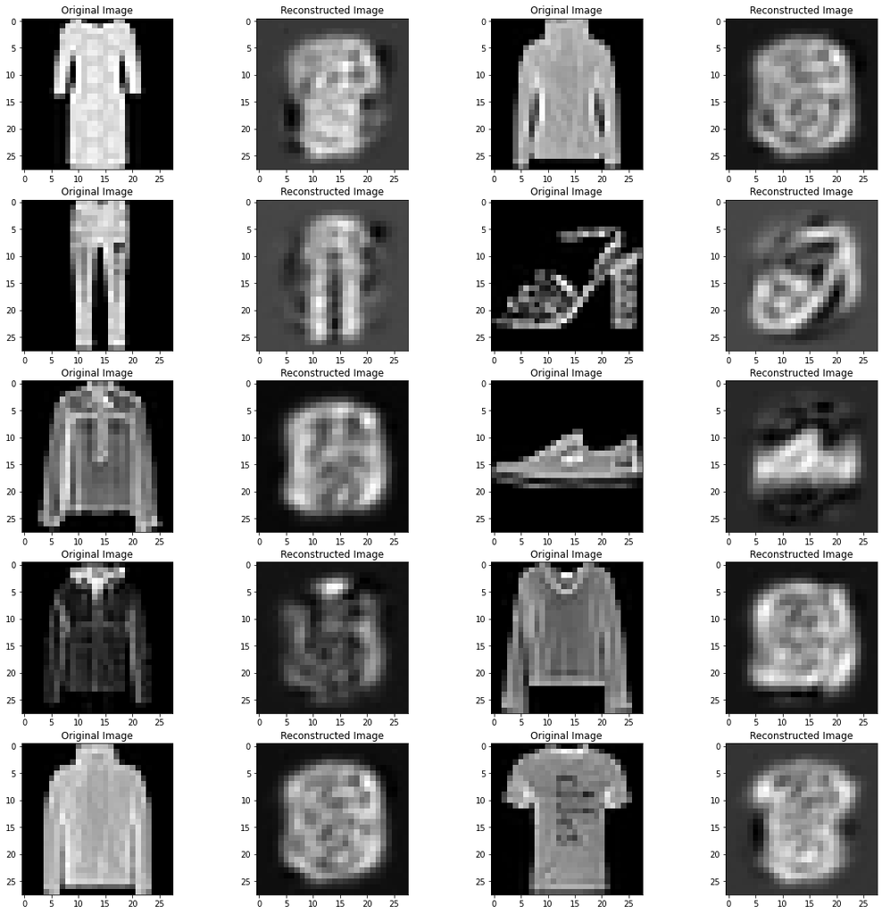

```python
fig, ax = plt.subplots(5, 4, figsize = (20, 20))
for i in range(10):
  r = i // 2
  c = 2 * (i % 2)
  idx = random.randint(0, len(fashion_data_test) - 1)
  image = inputs[idx].view(28, 28)
  image_hat = outputs[idx].view(28, 28)
  ax[r, c].imshow(image)
  ax[r, c + 1].imshow(image_hat.detach().numpy())
  ax[r, c].set_title('Original Image')
  ax[r, c + 1].set_title('Reconstructed Image')
```

### Random Noise images

```python
inputs = torch.randn(20, 1, 28, 28)
outputs = model(inputs)
```

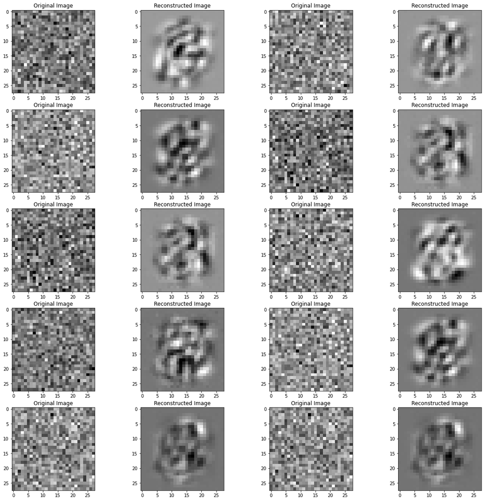

```python
fig, ax = plt.subplots(5, 4, figsize = (20, 20))
for i in range(10):
  r = i // 2
  c = 2 * (i % 2)
  idx = random.randint(0, len(inputs) - 1)
  image = inputs[idx].view(28, 28)
  image_hat = outputs[idx].view(28, 28)
  ax[r, c].imshow(image)
  ax[r, c + 1].imshow(image_hat.detach().numpy())
  ax[r, c].set_title('Original Image')
  ax[r, c + 1].set_title('Reconstructed Image')
```

### Latent dimension - 128

```python
model = AutoEncoder(latent_dim = 128)
```

```python
criterion = nn.MSELoss()
optimizer = optim.Adam(model.parameters(), lr = 0.001)
```

```python
train_costs = []
val_costs = []

for epoch in range(2):  # loop over the dataset multiple times

    running_loss = 0.0
    for i, data in enumerate(train_loader, 0):
        # get the inputs; data is a list of [inputs, labels]
        inputs, labels = data

        # zero the parameter gradients
        optimizer.zero_grad()

        # forward + backward + optimize
        outputs = model(inputs)
        loss = criterion(outputs, inputs.view(-1, 28*28))
        loss.backward()
        optimizer.step()

        if i % 200 == 0:
          train_costs.append(loss.item())
          for j, data in enumerate(val_loader, 0):
            inputs, labels = data
            outputs = model(inputs)
            val_loss = criterion(outputs, inputs.view(-1, 28*28))
            val_costs.append(val_loss.item())
          # Print Loss
          print('Epoch: {}. Iteration: {}. Train Loss: {}. Validation Loss: {}'.format(epoch, i, loss.item(), val_loss.item()))

print('Finished Training')
```

```
Epoch: 0. Iteration: 0. Train Loss: 0.11491896957159042. Validation Loss: 0.1138572096824646
Epoch: 0. Iteration: 200. Train Loss: 0.014322352595627308. Validation Loss: 0.014342386275529861
Epoch: 0. Iteration: 400. Train Loss: 0.008789483457803726. Validation Loss: 0.008903764188289642
Epoch: 0. Iteration: 600. Train Loss: 0.0065706949681043625. Validation Loss: 0.006969811394810677
Epoch: 1. Iteration: 0. Train Loss: 0.006526098120957613. Validation Loss: 0.006213210057467222
Epoch: 1. Iteration: 200. Train Loss: 0.006118045654147863. Validation Loss: 0.005615708418190479
Epoch: 1. Iteration: 400. Train Loss: 0.0052578947506845. Validation Loss: 0.005208589136600494
Epoch: 1. Iteration: 600. Train Loss: 0.00485427537932992. Validation Loss: 0.0049713384360075
Finished Training
```

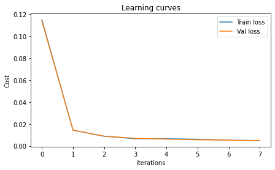

```python
# Plot the cost
plt.plot(train_costs)
plt.plot(val_costs)
plt.ylabel('Cost')
plt.xlabel('iterations')
plt.title('Learning curves')
plt.legend(['Train loss', 'Val loss'])
plt.show()
```

### Reconstruction Accuracy

```python
inputs, labels = iter(test_loader).next()
outputs = model(inputs)
```

```python
criterion(outputs, inputs.view(-1, 28*28))
```

```
tensor(0.0048, grad_fn=<MseLossBackward0>)
```

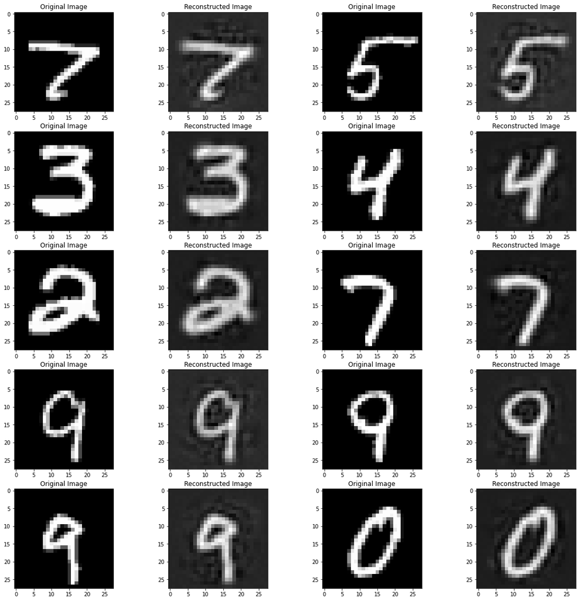

```python
fig, ax = plt.subplots(5, 4, figsize = (20, 20))
for i in range(10):
  r = i // 2
  c = 2 * (i % 2)
  idx = random.randint(0, len(mnist_data_test) - 1)
  image = inputs[idx].view(28, 28)
  image_hat = outputs[idx].view(28, 28)
  ax[r, c].imshow(image)
  ax[r, c + 1].imshow(image_hat.detach().numpy())
  ax[r, c].set_title('Original Image')
  ax[r, c + 1].set_title('Reconstructed Image')
```

### Fashion MNIST images

```python
inputs, labels = iter(fashion_test_loader).next()
outputs = model(inputs)
```

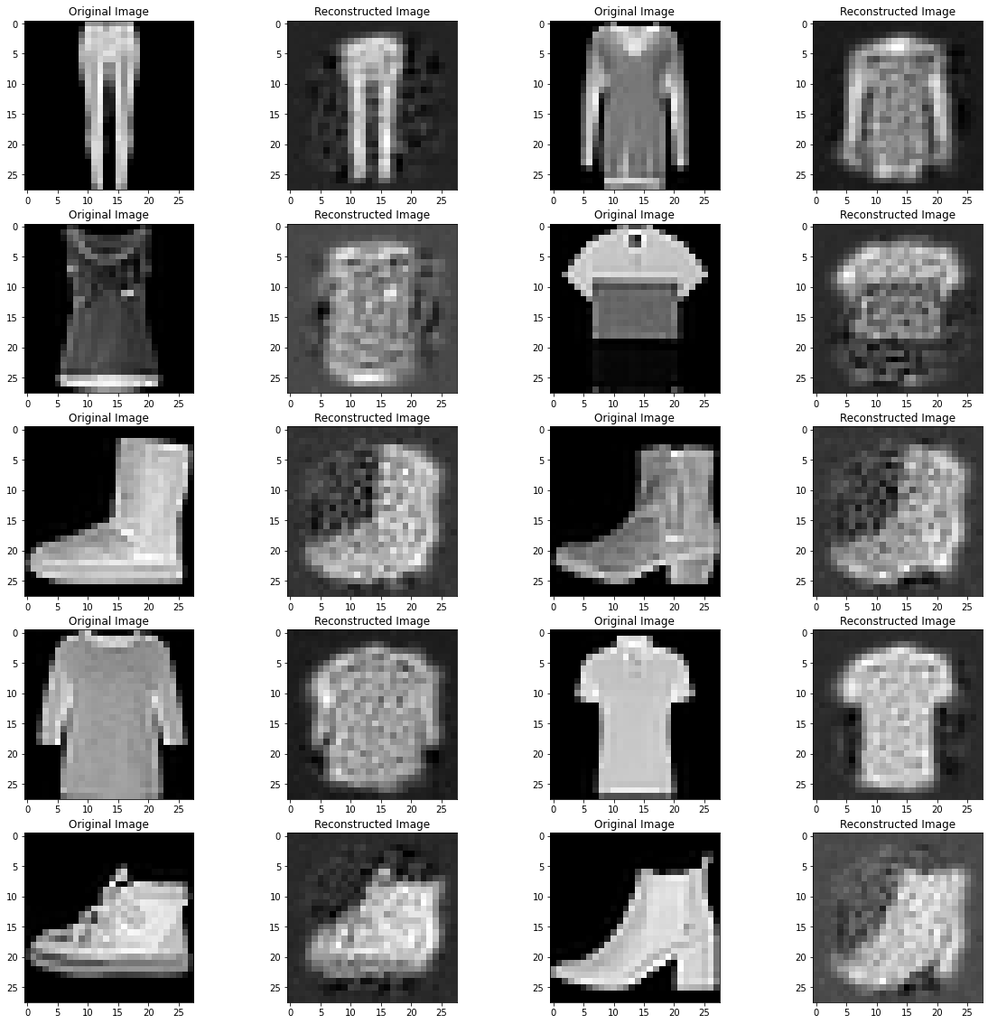

```python
fig, ax = plt.subplots(5, 4, figsize = (20, 20))
for i in range(10):
  r = i // 2
  c = 2 * (i % 2)
  idx = random.randint(0, len(fashion_data_test) - 1)
  image = inputs[idx].view(28, 28)
  image_hat = outputs[idx].view(28, 28)
  ax[r, c].imshow(image)
  ax[r, c + 1].imshow(image_hat.detach().numpy())
  ax[r, c].set_title('Original Image')
  ax[r, c + 1].set_title('Reconstructed Image')
```

### Random Noise images

```python
inputs = torch.randn(20, 1, 28, 28)
outputs = model(inputs)
```

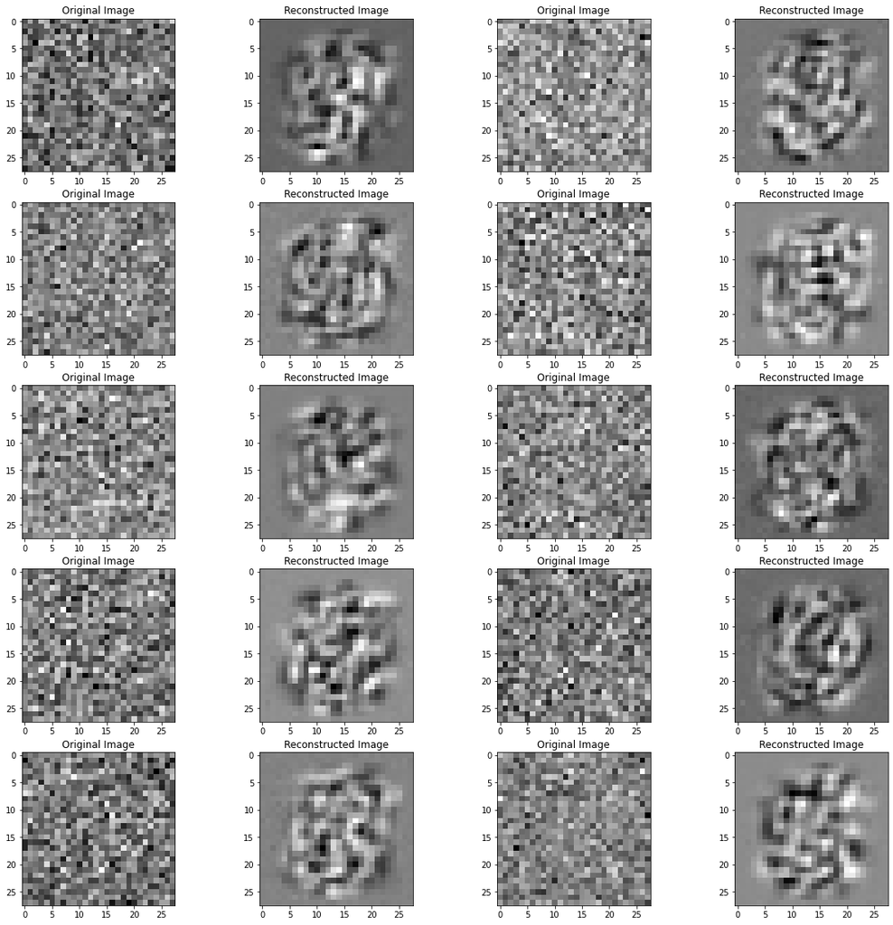

```python
fig, ax = plt.subplots(5, 4, figsize = (20, 20))
for i in range(10):
  r = i // 2
  c = 2 * (i % 2)
  idx = random.randint(0, len(inputs) - 1)
  image = inputs[idx].view(28, 28)
  image_hat = outputs[idx].view(28, 28)
  ax[r, c].imshow(image)
  ax[r, c + 1].imshow(image_hat.detach().numpy())
  ax[r, c].set_title('Original Image')
  ax[r, c + 1].set_title('Reconstructed Image')
```

### Latent dimension - 256

```python
model = AutoEncoder(latent_dim = 256)
```

```python
criterion = nn.MSELoss()
optimizer = optim.Adam(model.parameters(), lr = 0.001)
```

```python
train_costs = []
val_costs = []

for epoch in range(2):  # loop over the dataset multiple times

    running_loss = 0.0
    for i, data in enumerate(train_loader, 0):
        # get the inputs; data is a list of [inputs, labels]
        inputs, labels = data

        # zero the parameter gradients
        optimizer.zero_grad()

        # forward + backward + optimize
        outputs = model(inputs)
        loss = criterion(outputs, inputs.view(-1, 28*28))
        loss.backward()
        optimizer.step()

        if i % 200 == 0:
          train_costs.append(loss.item())
          for j, data in enumerate(val_loader, 0):
            inputs, labels = data
            outputs = model(inputs)
            val_loss = criterion(outputs, inputs.view(-1, 28*28))
            val_costs.append(val_loss.item())
          # Print Loss
          print('Epoch: {}. Iteration: {}. Train Loss: {}. Validation Loss: {}'.format(epoch, i, loss.item(), val_loss.item()))

print('Finished Training')
```

```
Epoch: 0. Iteration: 0. Train Loss: 0.1336650550365448. Validation Loss: 0.10880529135465622
Epoch: 0. Iteration: 200. Train Loss: 0.008603403344750404. Validation Loss: 0.009057732298970222
Epoch: 0. Iteration: 400. Train Loss: 0.005379675421863794. Validation Loss: 0.005218203645199537
Epoch: 0. Iteration: 600. Train Loss: 0.0035299884621053934. Validation Loss: 0.003785771084949374
Epoch: 1. Iteration: 0. Train Loss: 0.003463482717052102. Validation Loss: 0.0032121087424457073
Epoch: 1. Iteration: 200. Train Loss: 0.003053611144423485. Validation Loss: 0.0027192868292331696
Epoch: 1. Iteration: 400. Train Loss: 0.002366358879953623. Validation Loss: 0.002380548743531108
Epoch: 1. Iteration: 600. Train Loss: 0.0021210000850260258. Validation Loss: 0.002163427649065852
Finished Training
```

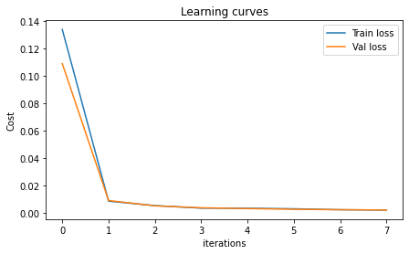

```python
# Plot the cost
plt.plot(train_costs)
plt.plot(val_costs)
plt.ylabel('Cost')
plt.xlabel('iterations')
plt.title('Learning curves')
plt.legend(['Train loss', 'Val loss'])
plt.show()
```

### Reconstruction Accuracy

```python
inputs, labels = iter(test_loader).next()
outputs = model(inputs)
```

```python
criterion(outputs, inputs.view(-1, 28*28))
```

```
tensor(0.0020, grad_fn=<MseLossBackward0>)
```

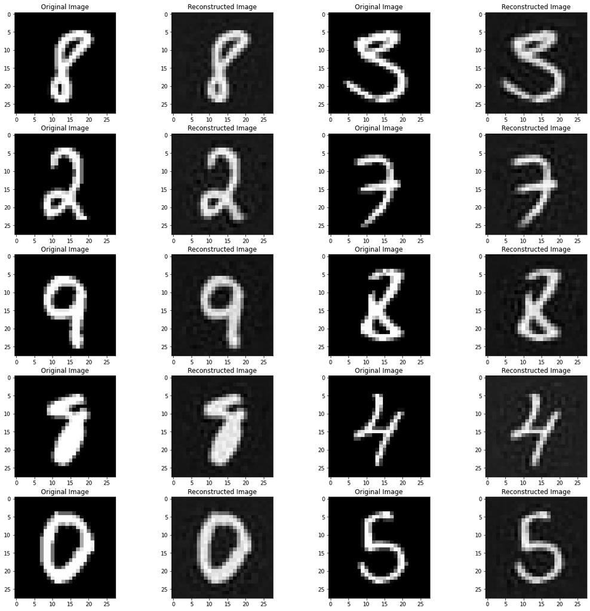

```python
fig, ax = plt.subplots(5, 4, figsize = (20, 20))
for i in range(10):
  r = i // 2
  c = 2 * (i % 2)
  idx = random.randint(0, len(mnist_data_test) - 1)
  image = inputs[idx].view(28, 28)
  image_hat = outputs[idx].view(28, 28)
  ax[r, c].imshow(image)
  ax[r, c + 1].imshow(image_hat.detach().numpy())
  ax[r, c].set_title('Original Image')
  ax[r, c + 1].set_title('Reconstructed Image')
```

### Fashion MNIST images

```python
inputs, labels = iter(fashion_test_loader).next()
outputs = model(inputs)
```

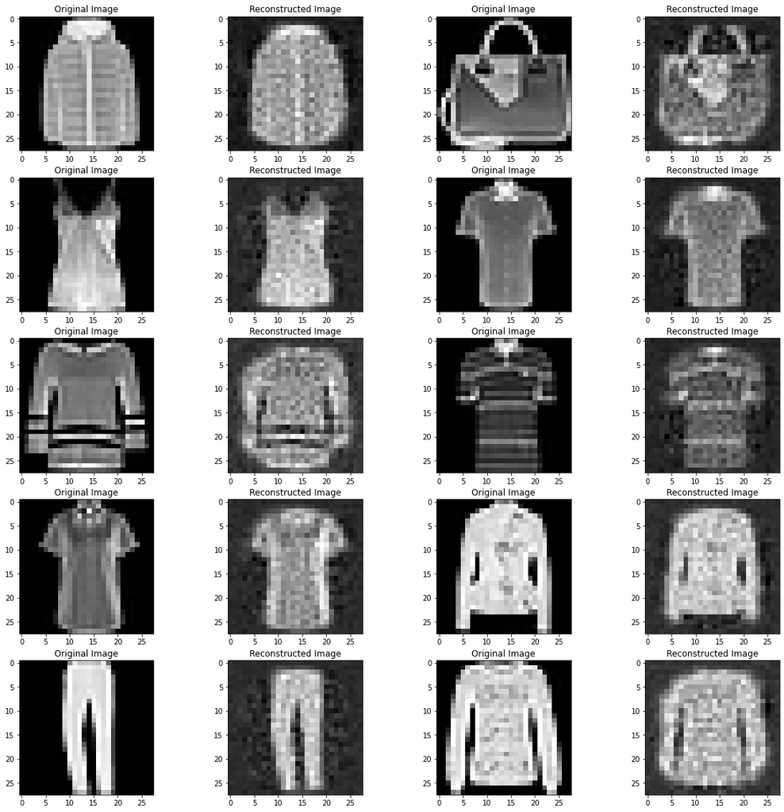

```python
fig, ax = plt.subplots(5, 4, figsize = (20, 20))
for i in range(10):
  r = i // 2
  c = 2 * (i % 2)
  idx = random.randint(0, len(fashion_data_test) - 1)
  image = inputs[idx].view(28, 28)
  image_hat = outputs[idx].view(28, 28)
  ax[r, c].imshow(image)
  ax[r, c + 1].imshow(image_hat.detach().numpy())
  ax[r, c].set_title('Original Image')
  ax[r, c + 1].set_title('Reconstructed Image')
```

### Random Noise images

```python
inputs = torch.randn(20, 1, 28, 28)
outputs = model(inputs)
```

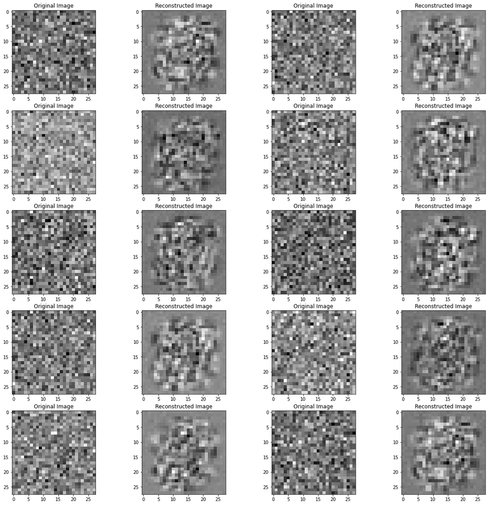

```python
fig, ax = plt.subplots(5, 4, figsize = (20, 20))
for i in range(10):
  r = i // 2
  c = 2 * (i % 2)
  idx = random.randint(0, len(inputs) - 1)
  image = inputs[idx].view(28, 28)
  image_hat = outputs[idx].view(28, 28)
  ax[r, c].imshow(image)
  ax[r, c + 1].imshow(image_hat.detach().numpy())
  ax[r, c].set_title('Original Image')
  ax[r, c + 1].set_title('Reconstructed Image')
```

1. As the size of the hidden code increases, the quality of the output (reconstructed) images increases. This can be confirmed by the increasing reconstruction accuracy
2. While passing Fashion MNIST images, the autoencoder with hidden code size as 256 is able to perform a good job of reconstructing. But the other autoencoders do not output a good reconstruction
3. None of the above networks are able to reconstruct random noise images

## Convolutional Autoencoders

### Unpooling + Deconvolution

```python
class Encoder(nn.Module):

    def __init__(self):
        super().__init__()
        self.conv1 = nn.Conv2d(1, 8, 3)
        self.pool1 = nn.MaxPool2d(2, return_indices = True)
        self.conv2 = nn.Conv2d(8, 16, 3)
        self.pool2 = nn.MaxPool2d(2, return_indices = True)
        self.conv3 = nn.Conv2d(16, 16, 3)
        self.pool3 = nn.MaxPool2d(2, return_indices = True)

    def forward(self, x):
        x = self.conv1(x)
        x, idx1 = self.pool1(x)
        x = self.conv2(x)
        x, idx2 = self.pool2(x)
        x = self.conv3(x)
        x, idx3 = self.pool3(x)
        return x, idx1, idx2, idx3
```

```python
class Decoder(nn.Module):

    def __init__(self):
        super().__init__()
        self.conv1 = nn.ConvTranspose2d(16, 16, 3)
        self.conv2 = nn.ConvTranspose2d(16, 16, 3)
        self.pool1 = nn.MaxUnpool2d(3, 2)
        self.conv3 = nn.ConvTranspose2d(16, 8, 3)
        self.pool2 = nn.MaxUnpool2d(2)
        self.conv4 = nn.ConvTranspose2d(8, 1, 3)

    def forward(self, x, idx1, idx2, idx3):
        x = self.conv1(x)
        x = self.conv2(x)
        x = self.pool1(x, idx2)
        x = self.conv3(x)
        x = self.pool2(x, idx1)
        x = self.conv4(x)
        return x
```

```python
class AutoEncoder(nn.Module):

    def __init__(self):
        super().__init__()
        self.encoder = Encoder()
        self.decoder = Decoder()

    def forward(self, x):
        h, idx1, idx2, idx3 = self.encoder(x)
        x_hat = self.decoder(h, idx1, idx2, idx3)
        return x_hat
```

```python
model = AutoEncoder()
```

```python
criterion = nn.MSELoss()
optimizer = optim.Adam(model.parameters(), lr = 0.001)
```

```python
train_costs = []
val_costs = []

for epoch in range(2):  # loop over the dataset multiple times

    running_loss = 0.0
    for i, data in enumerate(train_loader, 0):
        # get the inputs; data is a list of [inputs, labels]
        inputs, labels = data

        # zero the parameter gradients
        optimizer.zero_grad()

        # forward + backward + optimize
        outputs = model(inputs)
        loss = criterion(outputs, inputs)
        loss.backward()
        optimizer.step()

        if i % 200 == 0:
          train_costs.append(loss.item())
          for j, data in enumerate(val_loader, 0):
            inputs, labels = data
            outputs = model(inputs)
            val_loss = criterion(outputs, inputs)
            val_costs.append(val_loss.item())
          # Print Loss
          print('Epoch: {}. Iteration: {}. Train Loss: {}. Validation Loss: {}'.format(epoch, i, loss.item(), val_loss.item()))

print('Finished Training')
```

```
Epoch: 0. Iteration: 0. Train Loss: 0.10155656188726425. Validation Loss: 0.09895304590463638
Epoch: 0. Iteration: 200. Train Loss: 0.021431157365441322. Validation Loss: 0.02072582207620144
Epoch: 0. Iteration: 400. Train Loss: 0.013484550639986992. Validation Loss: 0.013809207826852798
Epoch: 0. Iteration: 600. Train Loss: 0.012252092361450195. Validation Loss: 0.012070137076079845
Epoch: 1. Iteration: 0. Train Loss: 0.011929936707019806. Validation Loss: 0.011432216502726078
Epoch: 1. Iteration: 200. Train Loss: 0.010617829859256744. Validation Loss: 0.010828993283212185
Epoch: 1. Iteration: 400. Train Loss: 0.011044465936720371. Validation Loss: 0.010411903262138367
Epoch: 1. Iteration: 600. Train Loss: 0.01096921507269144. Validation Loss: 0.0100692268460989
Finished Training
```

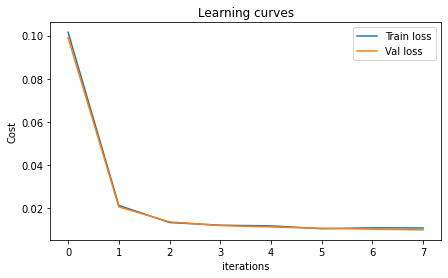

```python
# Plot the cost
plt.plot(train_costs)
plt.plot(val_costs)
plt.ylabel('Cost')
plt.xlabel('iterations')
plt.title('Learning curves')
plt.legend(['Train loss', 'Val loss'])
plt.show()
```

### Reconstruction Accuracy

```python
inputs, labels = iter(test_loader).next()
outputs = model(inputs)
```

```python
criterion(outputs, inputs)
```

```
tensor(0.0100, grad_fn=<MseLossBackward0>)
```

### Deconvolution

```python
class Encoder(nn.Module):

    def __init__(self):
        super().__init__()
        self.conv1 = nn.Conv2d(1, 8, 3)
        self.pool1 = nn.MaxPool2d(2, return_indices = True)
        self.conv2 = nn.Conv2d(8, 16, 3)
        self.pool2 = nn.MaxPool2d(2, return_indices = True)
        self.conv3 = nn.Conv2d(16, 16, 3)
        self.pool3 = nn.MaxPool2d(2, return_indices = True)

    def forward(self, x):
        x = self.conv1(x)
        x, idx1 = self.pool1(x)
        x = self.conv2(x)
        x, idx2 = self.pool2(x)
        x = self.conv3(x)
        x, idx3 = self.pool3(x)
        return x, idx1, idx2, idx3
```

```python
class Decoder(nn.Module):

    def __init__(self):
        super().__init__()
        self.conv1 = nn.ConvTranspose2d(16, 16, 10)
        self.conv2 = nn.ConvTranspose2d(16, 16, 7)
        self.conv3 = nn.ConvTranspose2d(16, 16, 5)
        self.conv4 = nn.ConvTranspose2d(16, 8, 5)
        self.conv5 = nn.ConvTranspose2d(8, 8, 3)
        self.conv6 = nn.ConvTranspose2d(8, 1, 3)

    def forward(self, x):
        x = self.conv1(x)
        x = self.conv2(x)
        x = self.conv3(x)
        x = self.conv4(x)
        x = self.conv5(x)
        x = self.conv6(x)
        return x
```

```python
class AutoEncoder(nn.Module):

    def __init__(self):
        super().__init__()
        self.encoder = Encoder()
        self.decoder = Decoder()

    def forward(self, x):
        h, idx1, idx2, idx3 = self.encoder(x)
        x_hat = self.decoder(h)
        return x_hat
```

```python
model = AutoEncoder()
```

```python
criterion = nn.MSELoss()
optimizer = optim.Adam(model.parameters(), lr = 0.001)
```

```python
train_costs = []
val_costs = []

for epoch in range(2):  # loop over the dataset multiple times

    running_loss = 0.0
    for i, data in enumerate(train_loader, 0):
        # get the inputs; data is a list of [inputs, labels]
        inputs, labels = data

        # zero the parameter gradients
        optimizer.zero_grad()

        # forward + backward + optimize
        outputs = model(inputs)
        loss = criterion(outputs, inputs)
        loss.backward()
        optimizer.step()

        if i % 200 == 0:
          train_costs.append(loss.item())
          for j, data in enumerate(val_loader, 0):
            inputs, labels = data
            outputs = model(inputs)
            val_loss = criterion(outputs, inputs)
            val_costs.append(val_loss.item())
          # Print Loss
          print('Epoch: {}. Iteration: {}. Train Loss: {}. Validation Loss: {}'.format(epoch, i, loss.item(), val_loss.item()))

print('Finished Training')
```

```
Epoch: 0. Iteration: 0. Train Loss: 0.209297776222229. Validation Loss: 0.1763347089290619
Epoch: 0. Iteration: 200. Train Loss: 0.04022906348109245. Validation Loss: 0.039927780628204346
Epoch: 0. Iteration: 400. Train Loss: 0.02983435057103634. Validation Loss: 0.033391304314136505
Epoch: 0. Iteration: 600. Train Loss: 0.030759256333112717. Validation Loss: 0.03186258301138878
Epoch: 1. Iteration: 0. Train Loss: 0.030499141663312912. Validation Loss: 0.03136676922440529
Epoch: 1. Iteration: 200. Train Loss: 0.03262246027588844. Validation Loss: 0.030787644907832146
Epoch: 1. Iteration: 400. Train Loss: 0.030112046748399734. Validation Loss: 0.030420048162341118
Epoch: 1. Iteration: 600. Train Loss: 0.02869493141770363. Validation Loss: 0.030029170215129852
Finished Training
```

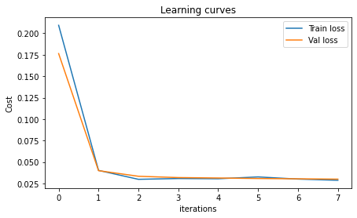

```python
# Plot the cost
plt.plot(train_costs)
plt.plot(val_costs)
plt.ylabel('Cost')
plt.xlabel('iterations')
plt.title('Learning curves')
plt.legend(['Train loss', 'Val loss'])
plt.show()
```

### Reconstruction Accuracy

```python
inputs, labels = iter(test_loader).next()
outputs = model(inputs)
```

```python
criterion(outputs, inputs)
```

```
tensor(0.0299, grad_fn=<MseLossBackward0>)
```

### Unpooling

```python
class Encoder(nn.Module):

    def __init__(self):
        super().__init__()
        self.conv1 = nn.Conv2d(1, 8, 3)
        self.pool1 = nn.MaxPool2d(2, return_indices = True)
        self.conv2 = nn.Conv2d(8, 16, 3)
        self.pool2 = nn.MaxPool2d(2, return_indices = True)
        self.conv3 = nn.Conv2d(16, 16, 3)
        self.pool3 = nn.MaxPool2d(2, return_indices = True)

    def forward(self, x):
        x = self.conv1(x)
        x, idx1 = self.pool1(x)
        x = self.conv2(x)
        x, idx2 = self.pool2(x)
        x = self.conv3(x)
        x, idx3 = self.pool3(x)
        return x, idx1, idx2, idx3
```

```python
class Decoder(nn.Module):

    def __init__(self):
        super().__init__()
        self.pool1 = nn.MaxUnpool2d(7)
        # self.pool2 = nn.MaxUnpool2d(5, 2)
        # self.pool3 = nn.MaxUnpool2d(4, 2)

    def forward(self, x, idx1, idx2, idx3):
        x = self.pool1(x, idx3)
        # x = self.pool2(x, idx2)
        # x = x[:, :8, :, :]
        # x = self.pool3(x, idx1)
        return x.view(-1, 1, 28, 28)
```

```python
class AutoEncoder(nn.Module):

    def __init__(self):
        super().__init__()
        self.encoder = Encoder()
        self.decoder = Decoder()

    def forward(self, x):
        h, idx1, idx2, idx3 = self.encoder(x)
        x_hat = self.decoder(h, idx1, idx2, idx3)
        return x_hat
```

```python
model = AutoEncoder()
```

```python
criterion = nn.MSELoss()
optimizer = optim.Adam(model.parameters(), lr = 0.001)
```

```python
train_costs = []
val_costs = []

for epoch in range(2):  # loop over the dataset multiple times

    running_loss = 0.0
    for i, data in enumerate(train_loader, 0):
        # get the inputs; data is a list of [inputs, labels]
        inputs, labels = data

        # zero the parameter gradients
        optimizer.zero_grad()

        # forward + backward + optimize
        outputs = model(inputs)
        loss = criterion(outputs, inputs)
        loss.backward()
        optimizer.step()

        if i % 200 == 0:
          train_costs.append(loss.item())
          for j, data in enumerate(val_loader, 0):
            inputs, labels = data
            outputs = model(inputs)
            val_loss = criterion(outputs, inputs)
            val_costs.append(val_loss.item())
          # Print Loss
          print('Epoch: {}. Iteration: {}. Train Loss: {}. Validation Loss: {}'.format(epoch, i, loss.item(), val_loss.item()))

print('Finished Training')
```

```
Epoch: 0. Iteration: 0. Train Loss: 0.11258353292942047. Validation Loss: 0.11147915571928024
Epoch: 0. Iteration: 200. Train Loss: 0.10590332746505737. Validation Loss: 0.10968124121427536
Epoch: 0. Iteration: 400. Train Loss: 0.11707111448049545. Validation Loss: 0.1094609871506691
Epoch: 0. Iteration: 600. Train Loss: 0.10498440265655518. Validation Loss: 0.10934877395629883
Epoch: 1. Iteration: 0. Train Loss: 0.11095767468214035. Validation Loss: 0.10930071771144867
Epoch: 1. Iteration: 200. Train Loss: 0.11146590858697891. Validation Loss: 0.1092464029788971
Epoch: 1. Iteration: 400. Train Loss: 0.1127355620265007. Validation Loss: 0.1092289462685585
Epoch: 1. Iteration: 600. Train Loss: 0.10413210839033127. Validation Loss: 0.10919477045536041
Finished Training
```

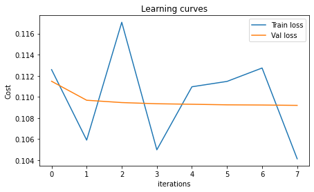

```python
# Plot the cost
plt.plot(train_costs)
plt.plot(val_costs)
plt.ylabel('Cost')
plt.xlabel('iterations')
plt.title('Learning curves')
plt.legend(['Train loss', 'Val loss'])
plt.show()
```

### Reconstruction Accuracy

```python
inputs, labels = iter(test_loader).next()
outputs = model(inputs)
```

```python
criterion(outputs, inputs)
```

```
tensor(0.1115, grad_fn=<MseLossBackward0>)
```

## Denoising Autoencoders

```python
class AutoEncoder(nn.Module):

    def __init__(self, latent_dim):
        super().__init__()
        self.encoder = nn.Sequential(nn.Flatten(),
                                     nn.Linear(784, latent_dim))
        self.decoder = nn.Sequential(nn.Linear(latent_dim, 784))

    def forward(self, x):
        h = self.encoder(x)
        x_hat = self.decoder(h)
        return x_hat
```

### Noise standard deviation - 0.3

```python
std = 0.3
```

```python
model = AutoEncoder(latent_dim = 256)
```

```python
criterion = nn.MSELoss()
optimizer = optim.Adam(model.parameters(), lr = 0.001)
```

```python
train_costs = []
val_costs = []

for epoch in range(5):  # loop over the dataset multiple times

    running_loss = 0.0
    for i, data in enumerate(train_loader, 0):
        # get the inputs; data is a list of [inputs, labels]
        inputs, labels = data
        noise_inputs = inputs + std * torch.randn(*inputs.shape)

        # zero the parameter gradients
        optimizer.zero_grad()

        # forward + backward + optimize
        outputs = model(noise_inputs)
        loss = criterion(outputs, inputs.view(-1, 28*28))
        loss.backward()
        optimizer.step()

        if i % 200 == 0:
          train_costs.append(loss.item())
          for j, data in enumerate(val_loader, 0):
            inputs, labels = data
            noise_inputs = inputs + std * torch.randn(*inputs.shape)
            outputs = model(noise_inputs)
            val_loss = criterion(outputs, inputs.view(-1, 28*28))
            val_costs.append(val_loss.item())
          # Print Loss
          print('Epoch: {}. Iteration: {}. Train Loss: {}. Validation Loss: {}'.format(epoch, i, loss.item(), val_loss.item()))

print('Finished Training')
```

```
Epoch: 0. Iteration: 0. Train Loss: 0.135969340801239. Validation Loss: 0.11885363608598709
Epoch: 0. Iteration: 200. Train Loss: 0.017505599185824394. Validation Loss: 0.017268836498260498
Epoch: 0. Iteration: 400. Train Loss: 0.014943120069801807. Validation Loss: 0.015019205398857594
Epoch: 0. Iteration: 600. Train Loss: 0.01472598034888506. Validation Loss: 0.014556796289980412
Epoch: 1. Iteration: 0. Train Loss: 0.015160087496042252. Validation Loss: 0.014359235763549805
Epoch: 1. Iteration: 200. Train Loss: 0.014142083004117012. Validation Loss: 0.014287808910012245
Epoch: 1. Iteration: 400. Train Loss: 0.014141525141894817. Validation Loss: 0.014135672710835934
Epoch: 1. Iteration: 600. Train Loss: 0.01426898967474699. Validation Loss: 0.014080684632062912
Epoch: 2. Iteration: 0. Train Loss: 0.01427158061414957. Validation Loss: 0.01400669850409031
Epoch: 2. Iteration: 200. Train Loss: 0.013446343131363392. Validation Loss: 0.013990041799843311
Epoch: 2. Iteration: 400. Train Loss: 0.014100510627031326. Validation Loss: 0.01397447008639574
Epoch: 2. Iteration: 600. Train Loss: 0.014235698617994785. Validation Loss: 0.014032295905053616
Epoch: 3. Iteration: 0. Train Loss: 0.014040605165064335. Validation Loss: 0.013972299173474312
Epoch: 3. Iteration: 200. Train Loss: 0.013716130517423153. Validation Loss: 0.013958858326077461
Epoch: 3. Iteration: 400. Train Loss: 0.014080144464969635. Validation Loss: 0.013945600017905235
Epoch: 3. Iteration: 600. Train Loss: 0.013832379132509232. Validation Loss: 0.013911623507738113
Epoch: 4. Iteration: 0. Train Loss: 0.014024131931364536. Validation Loss: 0.013927740976214409
Epoch: 4. Iteration: 200. Train Loss: 0.013772446662187576. Validation Loss: 0.01394675113260746
Epoch: 4. Iteration: 400. Train Loss: 0.013236490078270435. Validation Loss: 0.013865959830582142
Epoch: 4. Iteration: 600. Train Loss: 0.013833200559020042. Validation Loss: 0.013857315294444561
Finished Training
```

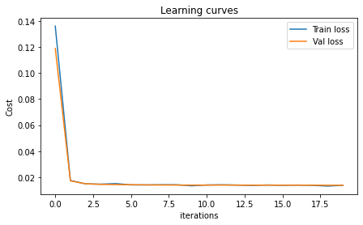

```python
# Plot the cost
plt.plot(train_costs)
plt.plot(val_costs)
plt.ylabel('Cost')
plt.xlabel('iterations')
plt.title('Learning curves')
plt.legend(['Train loss', 'Val loss'])
plt.show()
```

### Reconstruction Accuracy

```python
inputs, labels = iter(test_loader).next()
noise_inputs = inputs + std * torch.randn(*inputs.shape)
outputs = model(noise_inputs)
```

```python
criterion(outputs, inputs.view(-1, 28*28))
```

```
tensor(0.0137, grad_fn=<MseLossBackward0>)
```

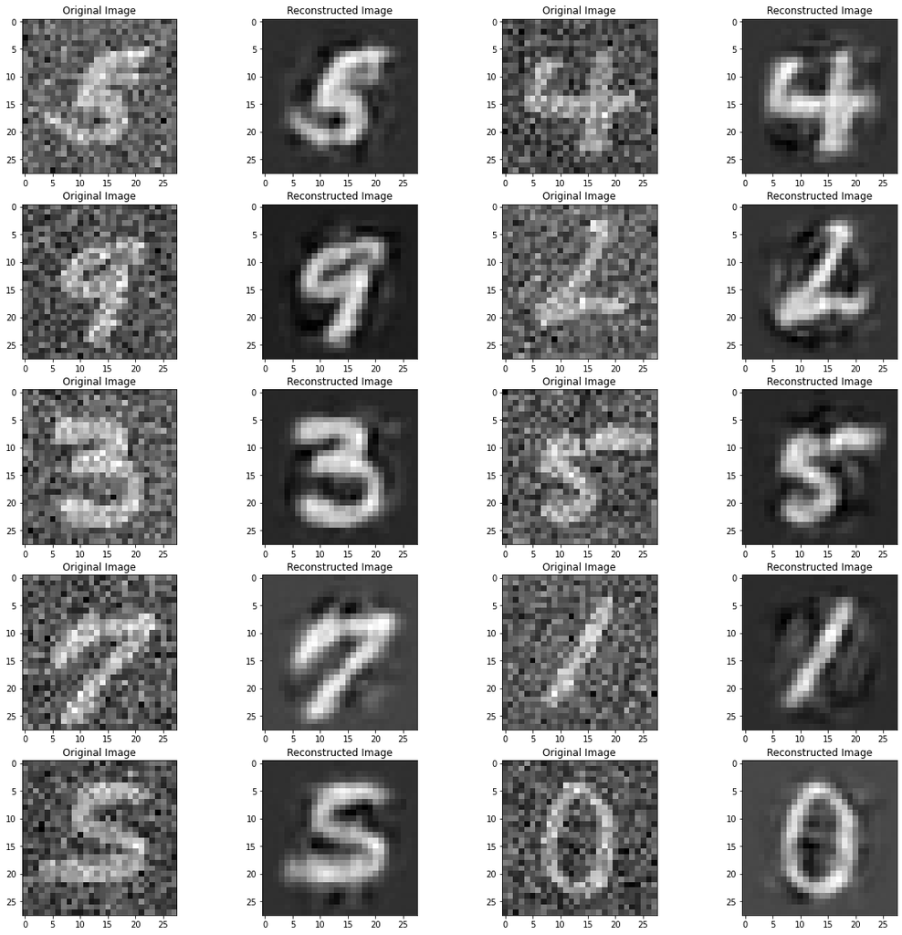

```python
fig, ax = plt.subplots(5, 4, figsize = (20, 20))
for i in range(10):
  r = i // 2
  c = 2 * (i % 2)
  idx = random.randint(0, len(mnist_data_test) - 1)
  image = noise_inputs[idx].view(28, 28)
  image_hat = outputs[idx].view(28, 28)
  ax[r, c].imshow(image)
  ax[r, c + 1].imshow(image_hat.detach().numpy())
  ax[r, c].set_title('Original Image')
  ax[r, c + 1].set_title('Reconstructed Image')
```

### Noise standard deviation - 0.5

```python
std = 0.5
```

```python
model = AutoEncoder(latent_dim = 256)
```

```python
criterion = nn.MSELoss()
optimizer = optim.Adam(model.parameters(), lr = 0.001)
```

```python
train_costs = []
val_costs = []

for epoch in range(5):  # loop over the dataset multiple times

    running_loss = 0.0
    for i, data in enumerate(train_loader, 0):
        # get the inputs; data is a list of [inputs, labels]
        inputs, labels = data
        noise_inputs = inputs + std * torch.randn(*inputs.shape)

        # zero the parameter gradients
        optimizer.zero_grad()

        # forward + backward + optimize
        outputs = model(noise_inputs)
        loss = criterion(outputs, inputs.view(-1, 28*28))
        loss.backward()
        optimizer.step()

        if i % 200 == 0:
          train_costs.append(loss.item())
          for j, data in enumerate(val_loader, 0):
            inputs, labels = data
            noise_inputs = inputs + std * torch.randn(*inputs.shape)
            outputs = model(noise_inputs)
            val_loss = criterion(outputs, inputs.view(-1, 28*28))
            val_costs.append(val_loss.item())
          # Print Loss
          print('Epoch: {}. Iteration: {}. Train Loss: {}. Validation Loss: {}'.format(epoch, i, loss.item(), val_loss.item()))

print('Finished Training')
```

```
Epoch: 0. Iteration: 0. Train Loss: 0.1531422734260559. Validation Loss: 0.13566052913665771
Epoch: 0. Iteration: 200. Train Loss: 0.024839872494339943. Validation Loss: 0.024805642664432526
Epoch: 0. Iteration: 400. Train Loss: 0.023460952565073967. Validation Loss: 0.023200081661343575
Epoch: 0. Iteration: 600. Train Loss: 0.02380235306918621. Validation Loss: 0.022767338901758194
Epoch: 1. Iteration: 0. Train Loss: 0.023690901696681976. Validation Loss: 0.022642292082309723
Epoch: 1. Iteration: 200. Train Loss: 0.02201862633228302. Validation Loss: 0.02259453758597374
Epoch: 1. Iteration: 400. Train Loss: 0.022648874670267105. Validation Loss: 0.022459212690591812
Epoch: 1. Iteration: 600. Train Loss: 0.023040594533085823. Validation Loss: 0.02241186797618866
Epoch: 2. Iteration: 0. Train Loss: 0.02213354781270027. Validation Loss: 0.022332701832056046
Epoch: 2. Iteration: 200. Train Loss: 0.021590841934084892. Validation Loss: 0.022299258038401604
Epoch: 2. Iteration: 400. Train Loss: 0.021939685568213463. Validation Loss: 0.022402944043278694
Epoch: 2. Iteration: 600. Train Loss: 0.02211037650704384. Validation Loss: 0.022295059636235237
Epoch: 3. Iteration: 0. Train Loss: 0.020763158798217773. Validation Loss: 0.022212626412510872
Epoch: 3. Iteration: 200. Train Loss: 0.022146938368678093. Validation Loss: 0.022240951657295227
Epoch: 3. Iteration: 400. Train Loss: 0.021730666980147362. Validation Loss: 0.02218635380268097
Epoch: 3. Iteration: 600. Train Loss: 0.02281823940575123. Validation Loss: 0.022230295464396477
Epoch: 4. Iteration: 0. Train Loss: 0.022870875895023346. Validation Loss: 0.02217387966811657
Epoch: 4. Iteration: 200. Train Loss: 0.022186819463968277. Validation Loss: 0.02213144488632679
Epoch: 4. Iteration: 400. Train Loss: 0.021395737305283546. Validation Loss: 0.02215201035141945
Epoch: 4. Iteration: 600. Train Loss: 0.02224809117615223. Validation Loss: 0.02205711044371128
Finished Training
```

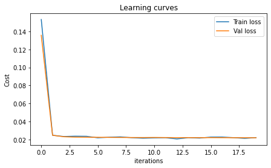

```python
# Plot the cost
plt.plot(train_costs)
plt.plot(val_costs)
plt.ylabel('Cost')
plt.xlabel('iterations')
plt.title('Learning curves')
plt.legend(['Train loss', 'Val loss'])
plt.show()
```

### Reconstruction Accuracy

```python
inputs, labels = iter(test_loader).next()
noise_inputs = inputs + std * torch.randn(*inputs.shape)
outputs = model(noise_inputs)
```

```python
criterion(outputs, inputs.view(-1, 28*28))
```

```
tensor(0.0219, grad_fn=<MseLossBackward0>)
```

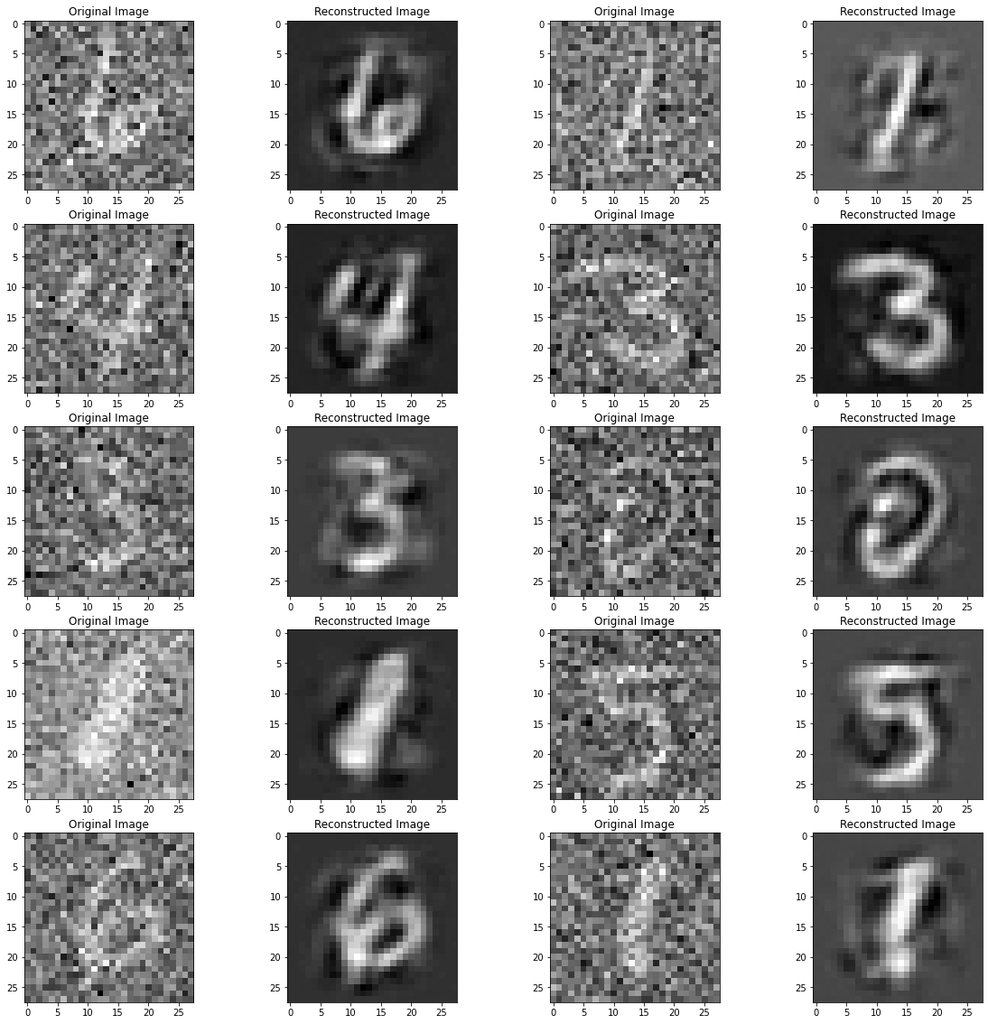

```python
fig, ax = plt.subplots(5, 4, figsize = (20, 20))
for i in range(10):
  r = i // 2
  c = 2 * (i % 2)
  idx = random.randint(0, len(mnist_data_test) - 1)
  image = noise_inputs[idx].view(28, 28)
  image_hat = outputs[idx].view(28, 28)
  ax[r, c].imshow(image)
  ax[r, c + 1].imshow(image_hat.detach().numpy())
  ax[r, c].set_title('Original Image')
  ax[r, c + 1].set_title('Reconstructed Image')
```

### Noise standard deviation - 0.8

```python
std = 0.8
```

```python
model = AutoEncoder(latent_dim = 256)
```

```python
criterion = nn.MSELoss()
optimizer = optim.Adam(model.parameters(), lr = 0.001)
```

```python
train_costs = []
val_costs = []

for epoch in range(5):  # loop over the dataset multiple times

    running_loss = 0.0
    for i, data in enumerate(train_loader, 0):
        # get the inputs; data is a list of [inputs, labels]
        inputs, labels = data
        noise_inputs = inputs + std * torch.randn(*inputs.shape)

        # zero the parameter gradients
        optimizer.zero_grad()

        # forward + backward + optimize
        outputs = model(noise_inputs)
        loss = criterion(outputs, inputs.view(-1, 28*28))
        loss.backward()
        optimizer.step()

        if i % 200 == 0:
          train_costs.append(loss.item())
          for j, data in enumerate(val_loader, 0):
            inputs, labels = data
            noise_inputs = inputs + std * torch.randn(*inputs.shape)
            outputs = model(noise_inputs)
            val_loss = criterion(outputs, inputs.view(-1, 28*28))
            val_costs.append(val_loss.item())
          # Print Loss
          print('Epoch: {}. Iteration: {}. Train Loss: {}. Validation Loss: {}'.format(epoch, i, loss.item(), val_loss.item()))

print('Finished Training')
```

```
Epoch: 0. Iteration: 0. Train Loss: 0.18892715871334076. Validation Loss: 0.181533083319664
Epoch: 0. Iteration: 200. Train Loss: 0.036030299961566925. Validation Loss: 0.03480768948793411
Epoch: 0. Iteration: 400. Train Loss: 0.03156370297074318. Validation Loss: 0.03333061560988426
Epoch: 0. Iteration: 600. Train Loss: 0.03390905633568764. Validation Loss: 0.03281644731760025
Epoch: 1. Iteration: 0. Train Loss: 0.033728841692209244. Validation Loss: 0.03282774239778519
Epoch: 1. Iteration: 200. Train Loss: 0.03199440985918045. Validation Loss: 0.03276090323925018
Epoch: 1. Iteration: 400. Train Loss: 0.031937334686517715. Validation Loss: 0.032626956701278687
Epoch: 1. Iteration: 600. Train Loss: 0.03345919027924538. Validation Loss: 0.032539572566747665
Epoch: 2. Iteration: 0. Train Loss: 0.03260520100593567. Validation Loss: 0.032528914511203766
Epoch: 2. Iteration: 200. Train Loss: 0.03329043090343475. Validation Loss: 0.032464589923620224
Epoch: 2. Iteration: 400. Train Loss: 0.03261939436197281. Validation Loss: 0.03248335421085358
Epoch: 2. Iteration: 600. Train Loss: 0.03300151973962784. Validation Loss: 0.032476481050252914
Epoch: 3. Iteration: 0. Train Loss: 0.03347393125295639. Validation Loss: 0.0322691984474659
Epoch: 3. Iteration: 200. Train Loss: 0.031952355057001114. Validation Loss: 0.03241758421063423
Epoch: 3. Iteration: 400. Train Loss: 0.03304386883974075. Validation Loss: 0.03221563249826431
Epoch: 3. Iteration: 600. Train Loss: 0.031887173652648926. Validation Loss: 0.03218168392777443
Epoch: 4. Iteration: 0. Train Loss: 0.03491481766104698. Validation Loss: 0.03230584040284157
Epoch: 4. Iteration: 200. Train Loss: 0.0312420055270195. Validation Loss: 0.03218967467546463
Epoch: 4. Iteration: 400. Train Loss: 0.03280024230480194. Validation Loss: 0.03212817385792732
Epoch: 4. Iteration: 600. Train Loss: 0.03052513487637043. Validation Loss: 0.03207401558756828
Finished Training
```

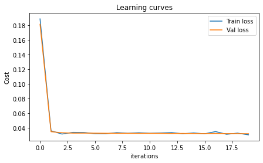

```python
# Plot the cost
plt.plot(train_costs)
plt.plot(val_costs)
plt.ylabel('Cost')
plt.xlabel('iterations')
plt.title('Learning curves')
plt.legend(['Train loss', 'Val loss'])
plt.show()
```

### Reconstruction Accuracy

```python
inputs, labels = iter(test_loader).next()
noise_inputs = inputs + std * torch.randn(*inputs.shape)
outputs = model(noise_inputs)
```

```python
criterion(outputs, inputs.view(-1, 28*28))
```

```
tensor(0.0318, grad_fn=<MseLossBackward0>)
```

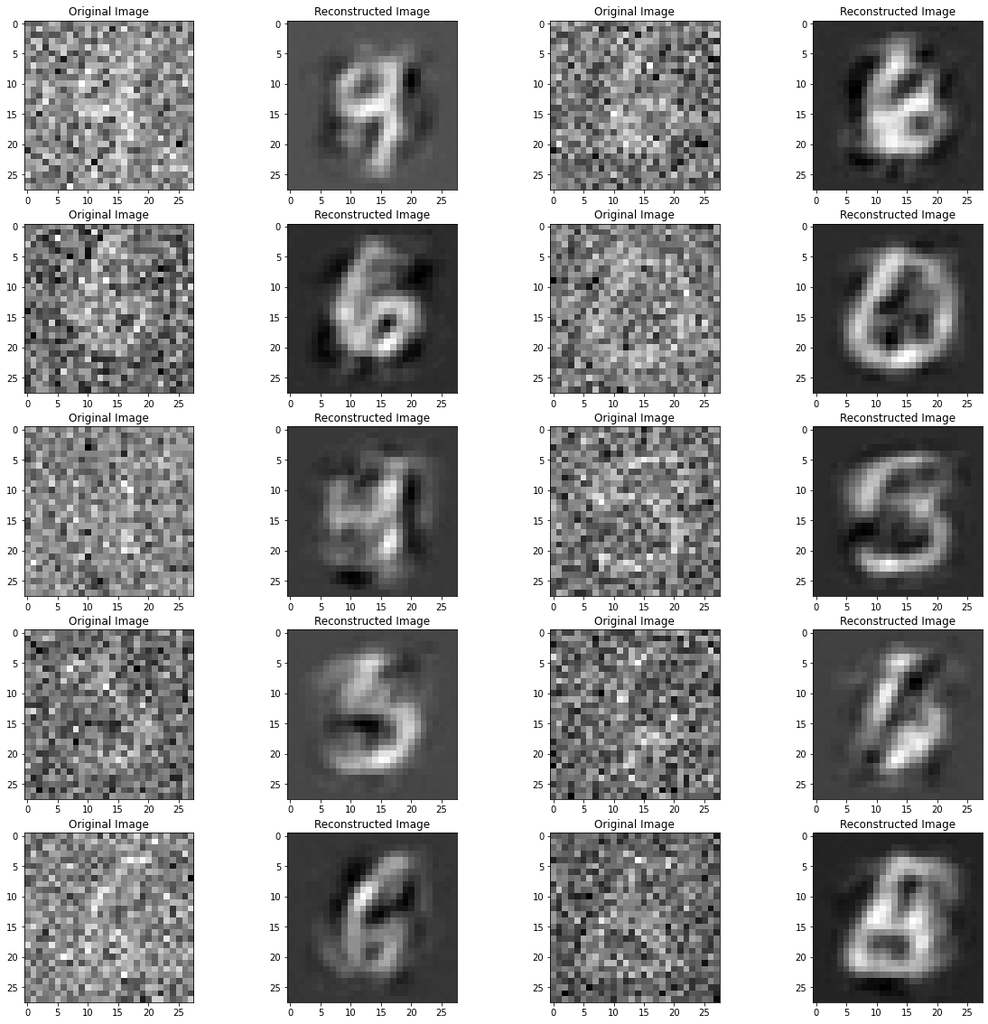

```python
fig, ax = plt.subplots(5, 4, figsize = (20, 20))
for i in range(10):
  r = i // 2
  c = 2 * (i % 2)
  idx = random.randint(0, len(mnist_data_test) - 1)
  image = noise_inputs[idx].view(28, 28)
  image_hat = outputs[idx].view(28, 28)
  ax[r, c].imshow(image)
  ax[r, c + 1].imshow(image_hat.detach().numpy())
  ax[r, c].set_title('Original Image')
  ax[r, c + 1].set_title('Reconstructed Image')
```

### Noise standard deviation - 0.9

```python
std = 0.9
```

```python
model = AutoEncoder(latent_dim = 256)
```

```python
criterion = nn.MSELoss()
optimizer = optim.Adam(model.parameters(), lr = 0.001)
```

```python
train_costs = []
val_costs = []

for epoch in range(5):  # loop over the dataset multiple times

    running_loss = 0.0
    for i, data in enumerate(train_loader, 0):
        # get the inputs; data is a list of [inputs, labels]
        inputs, labels = data
        noise_inputs = inputs + std * torch.randn(*inputs.shape)

        # zero the parameter gradients
        optimizer.zero_grad()

        # forward + backward + optimize
        outputs = model(noise_inputs)
        loss = criterion(outputs, inputs.view(-1, 28*28))
        loss.backward()
        optimizer.step()

        if i % 200 == 0:
          train_costs.append(loss.item())
          for j, data in enumerate(val_loader, 0):
            inputs, labels = data
            noise_inputs = inputs + std * torch.randn(*inputs.shape)
            outputs = model(noise_inputs)
            val_loss = criterion(outputs, inputs.view(-1, 28*28))
            val_costs.append(val_loss.item())
          # Print Loss
          print('Epoch: {}. Iteration: {}. Train Loss: {}. Validation Loss: {}'.format(epoch, i, loss.item(), val_loss.item()))

print('Finished Training')
```

```
Epoch: 0. Iteration: 0. Train Loss: 0.21152901649475098. Validation Loss: 0.19920067489147186
Epoch: 0. Iteration: 200. Train Loss: 0.03810093179345131. Validation Loss: 0.03769688680768013
Epoch: 0. Iteration: 400. Train Loss: 0.034411199390888214. Validation Loss: 0.03621918335556984
Epoch: 0. Iteration: 600. Train Loss: 0.03700074553489685. Validation Loss: 0.03594744950532913
Epoch: 1. Iteration: 0. Train Loss: 0.03690197318792343. Validation Loss: 0.035747431218624115
Epoch: 1. Iteration: 200. Train Loss: 0.035649802535772324. Validation Loss: 0.03578421473503113
Epoch: 1. Iteration: 400. Train Loss: 0.03770644962787628. Validation Loss: 0.03563607484102249
Epoch: 1. Iteration: 600. Train Loss: 0.0350600928068161. Validation Loss: 0.0353565514087677
Epoch: 2. Iteration: 0. Train Loss: 0.033051442354917526. Validation Loss: 0.03535957261919975
Epoch: 2. Iteration: 200. Train Loss: 0.03523603826761246. Validation Loss: 0.03542148321866989
Epoch: 2. Iteration: 400. Train Loss: 0.0348200760781765. Validation Loss: 0.035398662090301514
Epoch: 2. Iteration: 600. Train Loss: 0.033778753131628036. Validation Loss: 0.035285428166389465
Epoch: 3. Iteration: 0. Train Loss: 0.036098625510931015. Validation Loss: 0.035278696566820145
Epoch: 3. Iteration: 200. Train Loss: 0.03619932010769844. Validation Loss: 0.03512685373425484
Epoch: 3. Iteration: 400. Train Loss: 0.03599238023161888. Validation Loss: 0.03512977436184883
Epoch: 3. Iteration: 600. Train Loss: 0.0355294905602932. Validation Loss: 0.03510647267103195
Epoch: 4. Iteration: 0. Train Loss: 0.03451932221651077. Validation Loss: 0.03501516580581665
Epoch: 4. Iteration: 200. Train Loss: 0.03688633069396019. Validation Loss: 0.035034120082855225
Epoch: 4. Iteration: 400. Train Loss: 0.036251433193683624. Validation Loss: 0.03493938222527504
Epoch: 4. Iteration: 600. Train Loss: 0.035060495138168335. Validation Loss: 0.034954868257045746
Finished Training
```

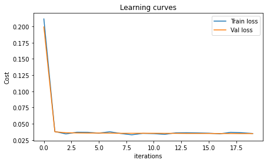

```python
# Plot the cost
plt.plot(train_costs)
plt.plot(val_costs)
plt.ylabel('Cost')
plt.xlabel('iterations')
plt.title('Learning curves')
plt.legend(['Train loss', 'Val loss'])
plt.show()
```

### Reconstruction Accuracy

```python
inputs, labels = iter(test_loader).next()
noise_inputs = inputs + std * torch.randn(*inputs.shape)
outputs = model(noise_inputs)
```

```python
criterion(outputs, inputs.view(-1, 28*28))
```

```
tensor(0.0347, grad_fn=<MseLossBackward0>)
```

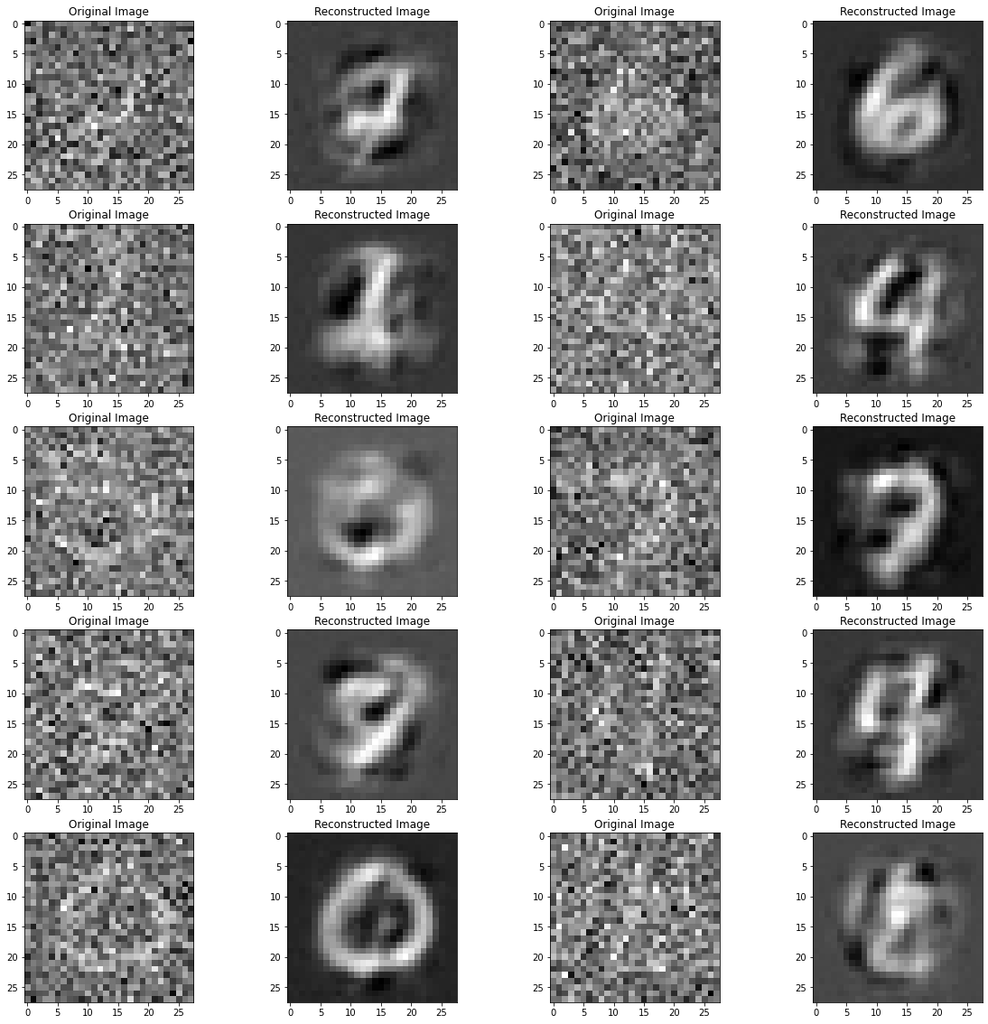

```python
fig, ax = plt.subplots(5, 4, figsize = (20, 20))
for i in range(10):
  r = i // 2
  c = 2 * (i % 2)
  idx = random.randint(0, len(mnist_data_test) - 1)
  image = noise_inputs[idx].view(28, 28)
  image_hat = outputs[idx].view(28, 28)
  ax[r, c].imshow(image)
  ax[r, c + 1].imshow(image_hat.detach().numpy())
  ax[r, c].set_title('Original Image')
  ax[r, c + 1].set_title('Reconstructed Image')
```

1. When an image with random noise is passed through a standard autoencoder, the reconstruction accuracy goes down. But a denoising autoencoder doe a good job of reconstructing the original image. Thus adding noise acts as a regularizer
2. As the standard deviation of the noise increases, the reconstruction accuracy and the reconstructed image quality decreases. This can be confirmed by visual inspection

## Sparse Autoencoders

```python
class AutoEncoder(nn.Module):

    def __init__(self, latent_dim):
        super().__init__()
        self.encoder = nn.Sequential(nn.Flatten(),
                                     nn.Linear(784, latent_dim))
        self.decoder = nn.Sequential(nn.Linear(latent_dim, 784))

    def forward(self, x):
        h = self.encoder(x)
        x_hat = self.decoder(h)
        return h, x_hat
```

### Regularization constant - 0.3

```python
alpha = 0.3
```

```python
latent_dim = 1000
model = AutoEncoder(latent_dim = latent_dim)
```

```python
criterion_1 = nn.MSELoss()
criterion_2 = nn.L1Loss()
optimizer = optim.Adam(model.parameters(), lr = 0.001)
```

```python
train_costs = []
val_costs = []

for epoch in range(5):  # loop over the dataset multiple times

    running_loss = 0.0
    for i, data in enumerate(train_loader, 0):
        # get the inputs; data is a list of [inputs, labels]
        inputs, labels = data

        # zero the parameter gradients
        optimizer.zero_grad()

        # forward + backward + optimize
        hidden, outputs = model(inputs)
        loss = criterion_1(outputs, inputs.view(-1, 28*28)) + alpha * criterion_2(hidden, torch.zeros(*hidden.shape))
        loss.backward()
        optimizer.step()

        if i % 200 == 0:
          train_costs.append(loss.item())
          for j, data in enumerate(val_loader, 0):
            inputs, labels = data
            hidden, outputs = model(inputs)
            val_loss = criterion_1(outputs, inputs.view(-1, 28*28)) + alpha * criterion_2(hidden, torch.zeros(*hidden.shape))
            val_costs.append(val_loss.item())
          # Print Loss
          print('Epoch: {}. Iteration: {}. Train Loss: {}. Validation Loss: {}'.format(epoch, i, loss.item(), val_loss.item()))

print('Finished Training')
```

```
Epoch: 0. Iteration: 0. Train Loss: 0.16672426462173462. Validation Loss: 0.13587263226509094
Epoch: 0. Iteration: 200. Train Loss: 0.02618531882762909. Validation Loss: 0.02599111944437027
Epoch: 0. Iteration: 400. Train Loss: 0.01885196752846241. Validation Loss: 0.018715061247348785
Epoch: 0. Iteration: 600. Train Loss: 0.01543072983622551. Validation Loss: 0.0155918188393116
Epoch: 1. Iteration: 0. Train Loss: 0.014628470875322819. Validation Loss: 0.014075372368097305
Epoch: 1. Iteration: 200. Train Loss: 0.012980910949409008. Validation Loss: 0.012933141551911831
Epoch: 1. Iteration: 400. Train Loss: 0.012507057748734951. Validation Loss: 0.01311582326889038
Epoch: 1. Iteration: 600. Train Loss: 0.010015146806836128. Validation Loss: 0.01072255615144968
Epoch: 2. Iteration: 0. Train Loss: 0.010193451307713985. Validation Loss: 0.010190101340413094
Epoch: 2. Iteration: 200. Train Loss: 0.009563394822180271. Validation Loss: 0.009800530970096588
Epoch: 2. Iteration: 400. Train Loss: 0.010145291686058044. Validation Loss: 0.009929466061294079
Epoch: 2. Iteration: 600. Train Loss: 0.009293139912188053. Validation Loss: 0.008996985852718353
Epoch: 3. Iteration: 0. Train Loss: 0.009656400419771671. Validation Loss: 0.009837405756115913
Epoch: 3. Iteration: 200. Train Loss: 0.008561543188989162. Validation Loss: 0.008973011747002602
Epoch: 3. Iteration: 400. Train Loss: 0.007941151037812233. Validation Loss: 0.007901018485426903
Epoch: 3. Iteration: 600. Train Loss: 0.007824196480214596. Validation Loss: 0.007675096392631531
Epoch: 4. Iteration: 0. Train Loss: 0.00806806143373251. Validation Loss: 0.007860234007239342
Epoch: 4. Iteration: 200. Train Loss: 0.0072109634056687355. Validation Loss: 0.007500245701521635
Epoch: 4. Iteration: 400. Train Loss: 0.007178576197475195. Validation Loss: 0.007435784209519625
Epoch: 4. Iteration: 600. Train Loss: 0.006880187429487705. Validation Loss: 0.006955702789127827
Finished Training
```

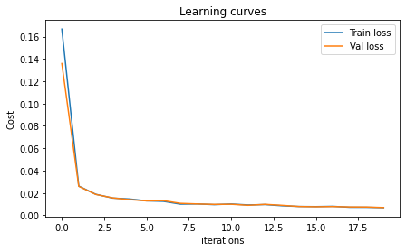

```python
# Plot the cost
plt.plot(train_costs)
plt.plot(val_costs)
plt.ylabel('Cost')
plt.xlabel('iterations')
plt.title('Learning curves')
plt.legend(['Train loss', 'Val loss'])
plt.show()
```

### Reconstruction Accuracy

```python
inputs, labels = iter(test_loader).next()
hidden, outputs = model(inputs)
```

```python
criterion_1(outputs, inputs.view(-1, 28*28))
```

```
tensor(0.0018, grad_fn=<MseLossBackward0>)
```

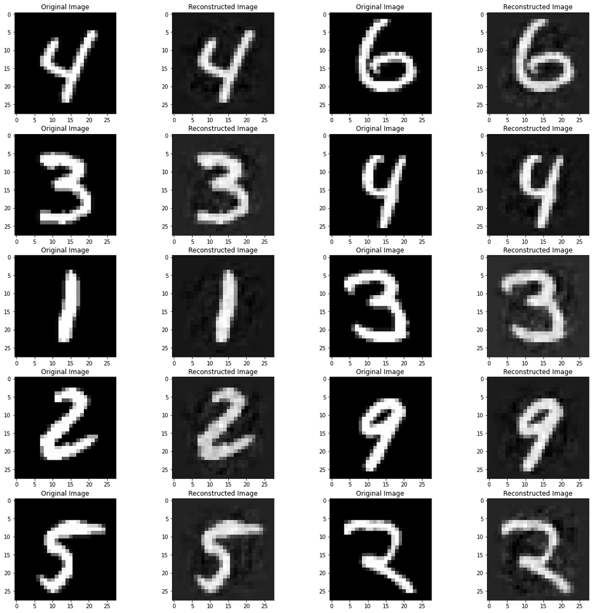

```python
fig, ax = plt.subplots(5, 4, figsize = (20, 20))
for i in range(10):
  r = i // 2
  c = 2 * (i % 2)
  idx = random.randint(0, len(mnist_data_test) - 1)
  image = inputs[idx].view(28, 28)
  image_hat = outputs[idx].view(28, 28)
  ax[r, c].imshow(image)
  ax[r, c + 1].imshow(image_hat.detach().numpy())
  ax[r, c].set_title('Original Image')
  ax[r, c + 1].set_title('Reconstructed Image')
```

### Regularization constant - 0.1

```python
alpha = 0.1
```

```python
latent_dim = 1000
model = AutoEncoder(latent_dim = latent_dim)
```

```python
criterion_1 = nn.MSELoss()
criterion_2 = nn.L1Loss()
optimizer = optim.Adam(model.parameters(), lr = 0.001)
```

```python
train_costs = []
val_costs = []

for epoch in range(5):  # loop over the dataset multiple times

    running_loss = 0.0
    for i, data in enumerate(train_loader, 0):
        # get the inputs; data is a list of [inputs, labels]
        inputs, labels = data

        # zero the parameter gradients
        optimizer.zero_grad()

        # forward + backward + optimize
        hidden, outputs = model(inputs)
        loss = criterion_1(outputs, inputs.view(-1, 28*28)) + alpha * criterion_2(hidden, torch.zeros(*hidden.shape))
        loss.backward()
        optimizer.step()

        if i % 200 == 0:
          train_costs.append(loss.item())
          for j, data in enumerate(val_loader, 0):
            inputs, labels = data
            hidden, outputs = model(inputs)
            val_loss = criterion_1(outputs, inputs.view(-1, 28*28)) + alpha * criterion_2(hidden, torch.zeros(*hidden.shape))
            val_costs.append(val_loss.item())
          # Print Loss
          print('Epoch: {}. Iteration: {}. Train Loss: {}. Validation Loss: {}'.format(epoch, i, loss.item(), val_loss.item()))

print('Finished Training')
```

```
Epoch: 0. Iteration: 0. Train Loss: 0.1381942182779312. Validation Loss: 0.10360480099916458
Epoch: 0. Iteration: 200. Train Loss: 0.01350127998739481. Validation Loss: 0.013836823403835297
Epoch: 0. Iteration: 400. Train Loss: 0.010072222910821438. Validation Loss: 0.010241292417049408
Epoch: 0. Iteration: 600. Train Loss: 0.008394676260650158. Validation Loss: 0.008301093243062496
Epoch: 1. Iteration: 0. Train Loss: 0.007493551354855299. Validation Loss: 0.007713180035352707
Epoch: 1. Iteration: 200. Train Loss: 0.007195983547717333. Validation Loss: 0.007260436192154884
Epoch: 1. Iteration: 400. Train Loss: 0.006115547381341457. Validation Loss: 0.0062018190510571
Epoch: 1. Iteration: 600. Train Loss: 0.005856962408870459. Validation Loss: 0.005945802200585604
Epoch: 2. Iteration: 0. Train Loss: 0.005239557474851608. Validation Loss: 0.0052657350897789
Epoch: 2. Iteration: 200. Train Loss: 0.00552069116383791. Validation Loss: 0.0052363937720656395
Epoch: 2. Iteration: 400. Train Loss: 0.00501604750752449. Validation Loss: 0.005034989677369595
Epoch: 2. Iteration: 600. Train Loss: 0.004294913727790117. Validation Loss: 0.0045580994337797165
Epoch: 3. Iteration: 0. Train Loss: 0.004244249779731035. Validation Loss: 0.004455700516700745
Epoch: 3. Iteration: 200. Train Loss: 0.004189305007457733. Validation Loss: 0.004294826649129391
Epoch: 3. Iteration: 400. Train Loss: 0.004255605861544609. Validation Loss: 0.004520000424236059
Epoch: 3. Iteration: 600. Train Loss: 0.003954021260142326. Validation Loss: 0.004153864923864603
Epoch: 4. Iteration: 0. Train Loss: 0.0036237938329577446. Validation Loss: 0.003881738055497408
Epoch: 4. Iteration: 200. Train Loss: 0.004039396997541189. Validation Loss: 0.004015229642391205
Epoch: 4. Iteration: 400. Train Loss: 0.003531477879732847. Validation Loss: 0.003937896806746721
Epoch: 4. Iteration: 600. Train Loss: 0.0035309246741235256. Validation Loss: 0.003533248556777835
Finished Training
```

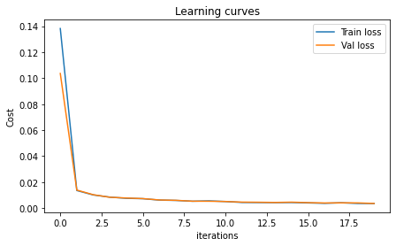

```python
# Plot the cost
plt.plot(train_costs)
plt.plot(val_costs)
plt.ylabel('Cost')
plt.xlabel('iterations')
plt.title('Learning curves')
plt.legend(['Train loss', 'Val loss'])
plt.show()
```

### Reconstruction Accuracy

```python
inputs, labels = iter(test_loader).next()
hidden, outputs = model(inputs)
```

```python
criterion_1(outputs, inputs.view(-1, 28*28))
```

```
tensor(0.0009, grad_fn=<MseLossBackward0>)
```

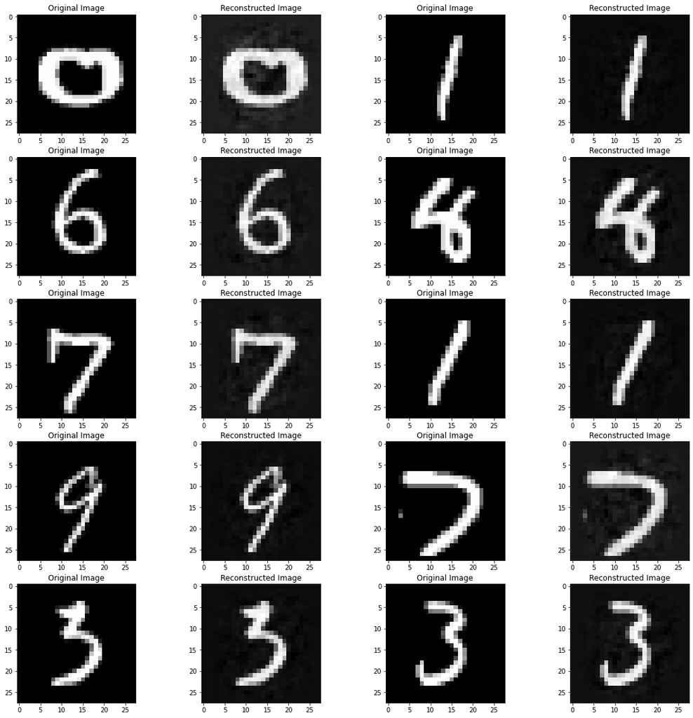

```python
fig, ax = plt.subplots(5, 4, figsize = (20, 20))
for i in range(10):
  r = i // 2
  c = 2 * (i % 2)
  idx = random.randint(0, len(mnist_data_test) - 1)
  image = inputs[idx].view(28, 28)
  image_hat = outputs[idx].view(28, 28)
  ax[r, c].imshow(image)
  ax[r, c + 1].imshow(image_hat.detach().numpy())
  ax[r, c].set_title('Original Image')
  ax[r, c + 1].set_title('Reconstructed Image')
```

### Regularization constant - 0.5

```python
alpha = 0.5
```

```python
latent_dim = 1000
model = AutoEncoder(latent_dim = latent_dim)
```

```python
criterion_1 = nn.MSELoss()
criterion_2 = nn.L1Loss()
optimizer = optim.Adam(model.parameters(), lr = 0.001)
```

```python
train_costs = []
val_costs = []

for epoch in range(5):  # loop over the dataset multiple times

    running_loss = 0.0
    for i, data in enumerate(train_loader, 0):
        # get the inputs; data is a list of [inputs, labels]
        inputs, labels = data

        # zero the parameter gradients
        optimizer.zero_grad()

        # forward + backward + optimize
        hidden, outputs = model(inputs)
        loss = criterion_1(outputs, inputs.view(-1, 28*28)) + alpha * criterion_2(hidden, torch.zeros(*hidden.shape))
        loss.backward()
        optimizer.step()

        if i % 200 == 0:
          train_costs.append(loss.item())
          for j, data in enumerate(val_loader, 0):
            inputs, labels = data
            hidden, outputs = model(inputs)
            val_loss = criterion_1(outputs, inputs.view(-1, 28*28)) + alpha * criterion_2(hidden, torch.zeros(*hidden.shape))
            val_costs.append(val_loss.item())
          # Print Loss
          print('Epoch: {}. Iteration: {}. Train Loss: {}. Validation Loss: {}'.format(epoch, i, loss.item(), val_loss.item()))

print('Finished Training')
```

```
Epoch: 0. Iteration: 0. Train Loss: 0.20840075612068176. Validation Loss: 0.16352501511573792
Epoch: 0. Iteration: 200. Train Loss: 0.03439889848232269. Validation Loss: 0.03499589487910271
Epoch: 0. Iteration: 400. Train Loss: 0.025882571935653687. Validation Loss: 0.025895357131958008
Epoch: 0. Iteration: 600. Train Loss: 0.02127017080783844. Validation Loss: 0.021097702905535698
Epoch: 1. Iteration: 0. Train Loss: 0.018666766583919525. Validation Loss: 0.01886708475649357
Epoch: 1. Iteration: 200. Train Loss: 0.0181642584502697. Validation Loss: 0.01778349280357361
Epoch: 1. Iteration: 400. Train Loss: 0.015397055074572563. Validation Loss: 0.01561732217669487
Epoch: 1. Iteration: 600. Train Loss: 0.014693211764097214. Validation Loss: 0.014613325707614422
Epoch: 2. Iteration: 0. Train Loss: 0.014947942458093166. Validation Loss: 0.0148611543700099
Epoch: 2. Iteration: 200. Train Loss: 0.012753568589687347. Validation Loss: 0.013271825388073921
Epoch: 2. Iteration: 400. Train Loss: 0.013331910595297813. Validation Loss: 0.012975655496120453
Epoch: 2. Iteration: 600. Train Loss: 0.013318629935383797. Validation Loss: 0.012146521359682083
Epoch: 3. Iteration: 0. Train Loss: 0.012853172607719898. Validation Loss: 0.01283530704677105
Epoch: 3. Iteration: 200. Train Loss: 0.011400596238672733. Validation Loss: 0.012189218774437904
Epoch: 3. Iteration: 400. Train Loss: 0.011859426274895668. Validation Loss: 0.011437353678047657
Epoch: 3. Iteration: 600. Train Loss: 0.011022273451089859. Validation Loss: 0.011343417689204216
Epoch: 4. Iteration: 0. Train Loss: 0.010431595146656036. Validation Loss: 0.010503250174224377
Epoch: 4. Iteration: 200. Train Loss: 0.011263741180300713. Validation Loss: 0.011024579405784607
Epoch: 4. Iteration: 400. Train Loss: 0.009971781633794308. Validation Loss: 0.010000523179769516
Epoch: 4. Iteration: 600. Train Loss: 0.009799710474908352. Validation Loss: 0.00962105393409729
Finished Training
```

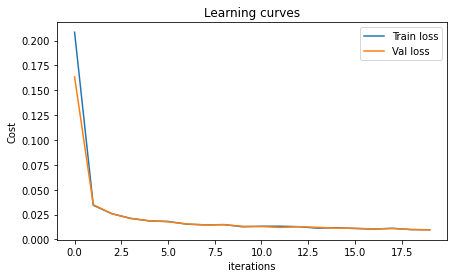

```python
# Plot the cost
plt.plot(train_costs)
plt.plot(val_costs)
plt.ylabel('Cost')
plt.xlabel('iterations')
plt.title('Learning curves')
plt.legend(['Train loss', 'Val loss'])
plt.show()
```